# Life Expectancy Analysis

## Introduction

This is an exercise in both exploratory and explanatory data visualization. We have acquired two datasets on life expectancy (in years) that contain information by country, gender, income level, and more. This data was obtained from the World Health Organization (WHO).

Source: https://www.kaggle.com/datasets/joebeachcapital/life-expectancy?select=WHOSIS_000001WHOSIS_000015WHOSIS_000002WHOSIS_000007.csv

In each section, we will explore the data and search for noteworthy trends. We will then generate visuals to display these trends in a clear, concise format.

## Outline

Part 1. Life Expectancy and Income Levels

Part 2. Life Expectancy and Gender

Part 3a. Life Expectancy by Country: vs. Global Average

Part 3b. Life Expectancy by Country: Country Net Change

```python
# Importing the Data
import pandas as pd
country_expectancy = pd.read_csv('xmart.csv')
income_expectancy = pd.read_csv('WHOSIS_000001WHOSIS_000015WHOSIS_000002WHOSIS_000007(1).csv')
```

## Initial Data Exploration

We have two datasets to explore:

`country_expectancy`: Life expectancy by country/territory/area

`income_expectancy`: Life expectancy by income group

```python
country_expectancy.head(8)
```

|  | Countries, territories and areas | Year | Life expectancy at birth (years) Both sexes | Life expectancy at birth (years) Male | Life expectancy at birth (years) Female | Life expectancy at age 60 (years) Both sexes | Life expectancy at age 60 (years) Male | Life expectancy at age 60 (years) Female | Healthy life expectancy (HALE) at birth (years) Both sexes | Healthy life expectancy (HALE) at birth (years) Male | Healthy life expectancy (HALE) at birth (years) Female | Healthy life expectancy (HALE) at age 60 (years) Both sexes | Healthy life expectancy (HALE) at age 60 (years) Male | Healthy life expectancy (HALE) at age 60 (years) Female |
| --- | --- | --- | --- | --- | --- | --- | --- | --- | --- | --- | --- | --- | --- | --- |
| 0 | Afghanistan | 2019 | 63.2 | 63.3 | 63.2 | 15.2 | 15.4 | 15.1 | 53.9 | 54.7 | 53.2 | 10.8 | 11.2 | 10.6 |
| 1 | Afghanistan | 2015 | 61.7 | 61.0 | 62.3 | 15.6 | 15.7 | 15.5 | 52.6 | 52.8 | 52.4 | 11.2 | 11.5 | 10.9 |
| 2 | Afghanistan | 2010 | 59.9 | 59.6 | 60.3 | 15.1 | 15.1 | 15.2 | 51.1 | 51.5 | 50.7 | 10.9 | 11.1 | 10.7 |
| 3 | Afghanistan | 2000 | 55.0 | 54.6 | 55.4 | 13.9 | 13.6 | 14.2 | 46.8 | 46.9 | 46.6 | 10.2 | 10.2 | 10.1 |
| 4 | Albania | 2019 | 78.0 | 76.3 | 79.9 | 21.0 | 20.2 | 21.9 | 69.1 | 68.0 | 70.3 | 16.6 | 15.9 | 17.3 |
| 5 | Albania | 2015 | 77.8 | 76.1 | 79.7 | 21.1 | 20.1 | 22.2 | 69.0 | 68.0 | 70.1 | 16.7 | 15.9 | 17.5 |
| 6 | Albania | 2010 | 76.2 | 74.2 | 78.3 | 21.3 | 19.9 | 22.6 | 67.6 | 66.3 | 68.9 | 16.7 | 15.7 | 17.7 |
| 7 | Albania | 2000 | 73.5 | 70.7 | 76.9 | 19.0 | 17.1 | 21.2 | 65.2 | 63.1 | 67.7 | 15.0 | 13.5 | 16.7 |

```python
income_expectancy.head(8)
```

|  | World Bank income group | Year | Life expectancy at birth (years) Both sexes | Life expectancy at birth (years) Male | Life expectancy at birth (years) Female | Life expectancy at age 60 (years) Both sexes | Life expectancy at age 60 (years) Male | Life expectancy at age 60 (years) Female | Healthy life expectancy (HALE) at birth (years) Both sexes | Healthy life expectancy (HALE) at birth (years) Male | Healthy life expectancy (HALE) at birth (years) Female | Healthy life expectancy (HALE) at age 60 (years) Both sexes | Healthy life expectancy (HALE) at age 60 (years) Male | Healthy life expectancy (HALE) at age 60 (years) Female |
| --- | --- | --- | --- | --- | --- | --- | --- | --- | --- | --- | --- | --- | --- | --- |
| 0 | Global | 2019 | 73.3 | 70.8 | 75.9 | 21.1 | 19.5 | 22.7 | 63.7 | 62.5 | 64.9 | 15.8 | 14.8 | 16.6 |
| 1 | Global | 2015 | 72.3 | 69.8 | 74.9 | 20.8 | 19.1 | 22.3 | 62.9 | 61.7 | 64.2 | 15.5 | 14.6 | 16.4 |
| 2 | Global | 2010 | 70.5 | 68.0 | 73.2 | 20.1 | 18.4 | 21.7 | 61.5 | 60.2 | 62.9 | 15.1 | 14.1 | 16.1 |
| 3 | Global | 2000 | 66.8 | 64.4 | 69.3 | 18.8 | 17.2 | 20.4 | 58.3 | 57.1 | 59.6 | 14.1 | 13.1 | 15.1 |
| 4 | Low-income | 2019 | 65.1 | 63.0 | 67.2 | 17.4 | 16.2 | 18.5 | 56.7 | 55.7 | 57.7 | 13.0 | 12.3 | 13.7 |
| 5 | Low-income | 2015 | 63.2 | 61.0 | 65.4 | 17.0 | 15.7 | 18.1 | 55.1 | 54.0 | 56.2 | 12.8 | 12.0 | 13.4 |
| 6 | Low-income | 2010 | 60.1 | 58.2 | 62.1 | 16.5 | 15.2 | 17.6 | 52.5 | 51.6 | 53.5 | 12.4 | 11.7 | 13.1 |
| 7 | Low-income | 2000 | 53.8 | 52.2 | 55.3 | 15.2 | 14.0 | 16.3 | 46.9 | 46.2 | 47.6 | 11.4 | 10.7 | 12.1 |

```python
country_expectancy.info()
```

```
<class 'pandas.core.frame.DataFrame'>
RangeIndex: 732 entries, 0 to 731
Data columns (total 14 columns):
 #   Column                                                        Non-Null Count  Dtype
---  ------                                                        --------------  -----
 0   Countries, territories and areas                              732 non-null    object
 1   Year                                                          732 non-null    int64
 2   Life expectancy at birth (years)  Both sexes                  732 non-null    float64
 3   Life expectancy at birth (years)  Male                        732 non-null    float64
 4   Life expectancy at birth (years)  Female                      732 non-null    float64
 5   Life expectancy at age 60 (years)  Both sexes                 732 non-null    float64
 6   Life expectancy at age 60 (years)  Male                       732 non-null    float64
 7   Life expectancy at age 60 (years)  Female                     732 non-null    float64
 8   Healthy life expectancy (HALE) at birth (years)  Both sexes   732 non-null    float64
 9   Healthy life expectancy (HALE) at birth (years)  Male         732 non-null    float64
 10  Healthy life expectancy (HALE) at birth (years)  Female       732 non-null    float64
 11  Healthy life expectancy (HALE) at age 60 (years)  Both sexes  732 non-null    float64
 12  Healthy life expectancy (HALE) at age 60 (years)  Male        732 non-null    float64
 13  Healthy life expectancy (HALE) at age 60 (years)  Female      732 non-null    float64
dtypes: float64(12), int64(1), object(1)
memory usage: 80.2+ KB
```

```python
income_expectancy.info()
```

```
<class 'pandas.core.frame.DataFrame'>
RangeIndex: 20 entries, 0 to 19
Data columns (total 14 columns):
 #   Column                                                        Non-Null Count  Dtype
---  ------                                                        --------------  -----
 0   World Bank income group                                       20 non-null     object
 1   Year                                                          20 non-null     int64
 2   Life expectancy at birth (years)  Both sexes                  20 non-null     float64
 3   Life expectancy at birth (years)  Male                        20 non-null     float64
 4   Life expectancy at birth (years)  Female                      20 non-null     float64
 5   Life expectancy at age 60 (years)  Both sexes                 20 non-null     float64
 6   Life expectancy at age 60 (years)  Male                       20 non-null     float64
 7   Life expectancy at age 60 (years)  Female                     20 non-null     float64
 8   Healthy life expectancy (HALE) at birth (years)  Both sexes   20 non-null     float64
 9   Healthy life expectancy (HALE) at birth (years)  Male         20 non-null     float64
 10  Healthy life expectancy (HALE) at birth (years)  Female       20 non-null     float64
 11  Healthy life expectancy (HALE) at age 60 (years)  Both sexes  20 non-null     float64
 12  Healthy life expectancy (HALE) at age 60 (years)  Male        20 non-null     float64
 13  Healthy life expectancy (HALE) at age 60 (years)  Female      20 non-null     float64
dtypes: float64(12), int64(1), object(1)
memory usage: 2.3+ KB
```

## Data Recap

We have data for 4 different years: 2000, 2010, 2015, and 2019.

For each year we have life expectancy at birth and at age 60, by gender, and with health adjustment (by country or by income group).

HALE (Health Adjusted Life Expectancy) assumes full health, no injury or illness.

The different income groups are: High, Upper-middle, Lower-middle, Low, and Global.

Lastly, this data has no null values, and has correct data typing. No cleaning seems to be necessary, so we may begin our analysis.

# Part 1: By Income

First, lets explore the effect of income on life expectancy, and look for trends between income groups over time.

```python
# Import Matplotlib
import matplotlib.pyplot as plt
%matplotlib inline
import matplotlib.style as style
style.use("fivethirtyeight")
```

```python
# Seperating Data by Income Level
global_expectancy = income_expectancy[income_expectancy['World Bank income group'] == ('Global')]
low_expectancy = income_expectancy[income_expectancy['World Bank income group'] == ('Low-income')]
low_mid_expectancy = income_expectancy[income_expectancy['World Bank income group'] == ('Lower-middle-income')]
upper_mid_expectancy = income_expectancy[income_expectancy['World Bank income group'] == ('Upper-middle-income')]
high_expectancy = income_expectancy[income_expectancy['World Bank income group'] == ('High-income')]
```

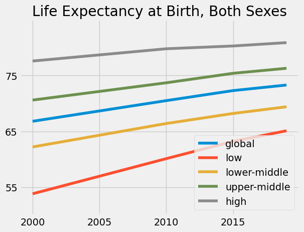

```python
# Life Expectancy at Birth vs. Income Level
plt.plot(global_expectancy['Year'], global_expectancy['Life expectancy at birth (years)  Both sexes'], label='global')
plt.plot(low_expectancy['Year'], low_expectancy['Life expectancy at birth (years)  Both sexes'], label='low')
plt.plot(low_mid_expectancy['Year'], low_mid_expectancy['Life expectancy at birth (years)  Both sexes'], label='lower-middle')
plt.plot(upper_mid_expectancy['Year'], upper_mid_expectancy['Life expectancy at birth (years)  Both sexes'], label='upper-middle')
plt.plot(high_expectancy['Year'], high_expectancy['Life expectancy at birth (years)  Both sexes'], label='high')
plt.title('Life Expectancy at Birth, Both Sexes')
plt.xticks([2000, 2005, 2010, 2015])
plt.ylim(50,85)
plt.yticks([55,65,75])
plt.legend()
plt.show()
```

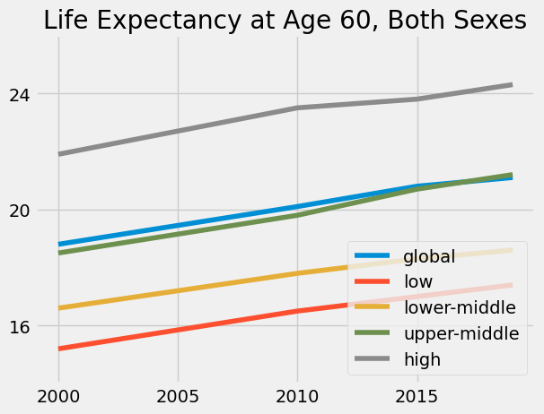

```python
# Life Expectancy at Age 60 vs. Income Level
plt.plot(global_expectancy['Year'], global_expectancy['Life expectancy at age 60 (years)  Both sexes'], label='global')
plt.plot(low_expectancy['Year'], low_expectancy['Life expectancy at age 60 (years)  Both sexes'], label='low')
plt.plot(low_mid_expectancy['Year'], low_mid_expectancy['Life expectancy at age 60 (years)  Both sexes'], label='lower-middle')
plt.plot(upper_mid_expectancy['Year'], upper_mid_expectancy['Life expectancy at age 60 (years)  Both sexes'], label='upper-middle')
plt.plot(high_expectancy['Year'], high_expectancy['Life expectancy at age 60 (years)  Both sexes'], label='high')
plt.title('Life Expectancy at Age 60, Both Sexes')
plt.xticks([2000, 2005, 2010, 2015])
plt.ylim(14,26)
plt.yticks([16,20,24])
plt.legend(loc='lower right')
plt.show()
```

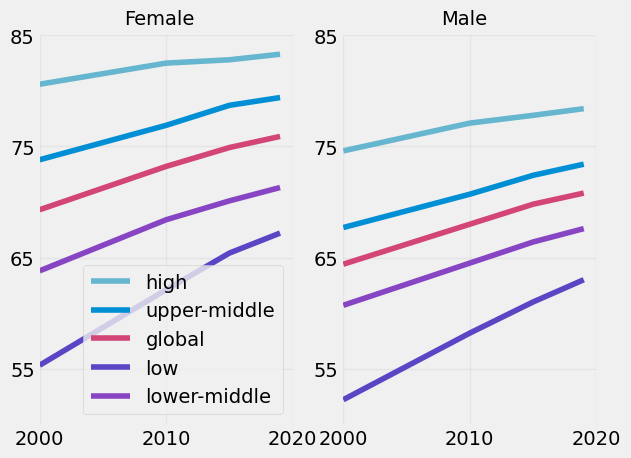

```python
# Life Expectancy by Gender vs. Income Level
plt.figure()
ax1 = plt.subplot(1,2,1)
ax2 = plt.subplot(1,2,2)

# Female
ax1.plot(high_expectancy['Year'], high_expectancy['Life expectancy at birth (years)  Female'], label='high', color='#67b6d0')
ax1.plot(upper_mid_expectancy['Year'], upper_mid_expectancy['Life expectancy at birth (years)  Female'], label='upper-middle')
ax1.plot(global_expectancy['Year'], global_expectancy['Life expectancy at birth (years)  Female'], label='global', color='#d34577')
ax1.plot(low_expectancy['Year'], low_expectancy['Life expectancy at birth (years)  Female'], label='low', color='#5c45c4')
ax1.plot(low_mid_expectancy['Year'], low_mid_expectancy['Life expectancy at birth (years)  Female'], label='lower-middle', color='#8745c4')
ax1.grid(alpha=0.3)
ax1.set_xlim(2000,2019)
ax1.set_xticks([2000,2010,2020])
ax1.tick_params(bottom=False, left=False)
ax1.set_ylim(50,85)
ax1.set_yticks([55,65,75,85])
ax1.text(x=2006.7, y=86, s='Female', fontsize=14)
ax1.legend(loc='lower right')

# Male
ax2.plot(high_expectancy['Year'], high_expectancy['Life expectancy at birth (years)  Male'], label='high', color='#67b6d0')
ax2.plot(upper_mid_expectancy['Year'], upper_mid_expectancy['Life expectancy at birth (years)  Male'], label='upper-middle')
ax2.plot(global_expectancy['Year'], global_expectancy['Life expectancy at birth (years)  Male'], label='global', color='#d34577')
ax2.plot(low_expectancy['Year'], low_expectancy['Life expectancy at birth (years)  Male'], label='low', color='#5c45c4')
ax2.plot(low_mid_expectancy['Year'], low_mid_expectancy['Life expectancy at birth (years)  Male'], label='lower-middle', color='#8745c4')
ax2.grid(alpha=0.3)
ax2.set_xlim(2000,2019)
ax2.set_xticks([2000,2010,2020])
ax2.set_ylim(50,85)
ax2.set_yticks([55,65,75,85])
ax2.tick_params(bottom=False, left=False)
ax2.text(x=2007.7, y=86, s='Male', fontsize=14)

for spine in ['top', 'bottom', 'left', 'right']:
    ax1.spines[spine].set_visible(False)
    ax2.spines[spine].set_visible(False)

plt.show()
```

## Income Life Expectancy Gap

Upon closer inspection of these graphs, the gap between low and high income life expectancy at birth seems to be decreasing over time; meanwhile, the gap for life expectancy at 60 doesn't seem to be closing in the same manner. Let's calculate these differences.

```python
# Life Expectancy Change between Income Levels over Time, at Birth

years = [2000,2010,2015,2019]
incomes = ['Global', 'Low-income', 'Lower-middle-income', 'Upper-middle-income', 'High-income']

wealth_data_birth = pd.DataFrame(data={'Year': years})

for year in years:

        data = income_expectancy[income_expectancy['Year'] == year]

        high_income = data[data['World Bank income group'] == 'High-income']
        high_val = high_income['Life expectancy at birth (years)  Both sexes'].astype(float).iloc[0]

        low_income = data[data['World Bank income group'] == 'Low-income']
        low_val = low_income['Life expectancy at birth (years)  Both sexes'].astype(float).iloc[0]

        global_income = data[data['World Bank income group'] == 'Global']
        global_val = global_income['Life expectancy at birth (years)  Both sexes'].astype(float).iloc[0]

        wealth_factor = high_val - global_val
        poor_factor = low_val - global_val
        total_spread = high_val - low_val

        wealth_data_birth.loc[wealth_data_birth['Year'] == year, 'wealth_factor'] = wealth_factor
        wealth_data_birth.loc[wealth_data_birth['Year'] == year, 'poor_factor'] = poor_factor
        wealth_data_birth.loc[wealth_data_birth['Year'] == year, 'total_spread'] = total_spread


wealth_data_birth
```

|  | Year | wealth_factor | poor_factor | total_spread |
| --- | --- | --- | --- | --- |
| 0 | 2000 | 10.8 | -13.0 | 23.8 |
| 1 | 2010 | 9.3 | -10.4 | 19.7 |
| 2 | 2015 | 8.0 | -9.1 | 17.1 |
| 3 | 2019 | 7.6 | -8.2 | 15.8 |

```python
# Life Expectancy Change between Income Levels over Time, at Age 60

wealth_data_60 = pd.DataFrame(data={'Year': years})

for year in years:

        data = income_expectancy[income_expectancy['Year'] == year]

        high_income = data[data['World Bank income group'] == 'High-income']
        high_val = high_income['Life expectancy at age 60 (years)  Both sexes'].astype(float).iloc[0]

        low_income = data[data['World Bank income group'] == 'Low-income']
        low_val = low_income['Life expectancy at age 60 (years)  Both sexes'].astype(float).iloc[0]

        global_income = data[data['World Bank income group'] == 'Global']
        global_val = global_income['Life expectancy at age 60 (years)  Both sexes'].astype(float).iloc[0]

        wealth_factor = high_val - global_val
        poor_factor = low_val - global_val
        total_spread = high_val - low_val


        wealth_data_60.loc[wealth_data_60['Year'] == year, 'wealth_factor'] = wealth_factor
        wealth_data_60.loc[wealth_data_60['Year'] == year, 'poor_factor'] = poor_factor
        wealth_data_60.loc[wealth_data_60['Year'] == year, 'total_spread'] = total_spread


wealth_data_60
```

|  | Year | wealth_factor | poor_factor | total_spread |
| --- | --- | --- | --- | --- |
| 0 | 2000 | 3.1 | -3.6 | 6.7 |
| 1 | 2010 | 3.4 | -3.6 | 7.0 |
| 2 | 2015 | 3.0 | -3.8 | 6.8 |
| 3 | 2019 | 3.2 | -3.7 | 6.9 |

```python
# Life Expectancy Change between Income Levels over Time, at Birth HALE

wealth_data_birth_hale = pd.DataFrame(data={'Year': years})

for year in years:

        data = income_expectancy[income_expectancy['Year'] == year]

        high_income = data[data['World Bank income group'] == 'High-income']
        high_val = high_income['Healthy life expectancy (HALE) at birth (years)  Both sexes'].astype(float).iloc[0]

        low_income = data[data['World Bank income group'] == 'Low-income']
        low_val = low_income['Healthy life expectancy (HALE) at birth (years)  Both sexes'].astype(float).iloc[0]

        global_income = data[data['World Bank income group'] == 'Global']
        global_val = global_income['Healthy life expectancy (HALE) at birth (years)  Both sexes'].astype(float).iloc[0]

        wealth_factor = high_val - global_val
        poor_factor = low_val - global_val
        total_spread = high_val - low_val

        wealth_data_birth_hale.loc[wealth_data_birth_hale['Year'] == year, 'wealth_factor'] = wealth_factor
        wealth_data_birth_hale.loc[wealth_data_birth_hale['Year'] == year, 'poor_factor'] = poor_factor
        wealth_data_birth_hale.loc[wealth_data_birth_hale['Year'] == year, 'total_spread'] = total_spread


wealth_data_birth_hale
```

|  | Year | wealth_factor | poor_factor | total_spread |
| --- | --- | --- | --- | --- |
| 0 | 2000 | 9.4 | -11.4 | 20.8 |
| 1 | 2010 | 7.8 | -9.0 | 16.8 |
| 2 | 2015 | 6.7 | -7.8 | 14.5 |
| 3 | 2019 | 6.1 | -7.0 | 13.1 |

```python
# Life Expectancy Change between Income Levels over Time, at Age 60 HALE

wealth_data_60_hale = pd.DataFrame(data={'Year': years})

for year in years:

        data = income_expectancy[income_expectancy['Year'] == year]

        high_income = data[data['World Bank income group'] == 'High-income']
        high_val = high_income['Healthy life expectancy (HALE) at age 60 (years)  Both sexes'].astype(float).iloc[0]

        low_income = data[data['World Bank income group'] == 'Low-income']
        low_val = low_income['Healthy life expectancy (HALE) at age 60 (years)  Both sexes'].astype(float).iloc[0]

        global_income = data[data['World Bank income group'] == 'Global']
        global_val = global_income['Healthy life expectancy (HALE) at age 60 (years)  Both sexes'].astype(float).iloc[0]

        wealth_factor = high_val - global_val
        poor_factor = low_val - global_val
        total_spread = high_val - low_val

        wealth_data_60_hale.loc[wealth_data_60_hale['Year'] == year, 'wealth_factor'] = wealth_factor
        wealth_data_60_hale.loc[wealth_data_60_hale['Year'] == year, 'poor_factor'] = poor_factor
        wealth_data_60_hale.loc[wealth_data_60_hale['Year'] == year, 'total_spread'] = total_spread


wealth_data_60_hale
```

|  | Year | wealth_factor | poor_factor | total_spread |
| --- | --- | --- | --- | --- |
| 0 | 2000 | 2.5 | -2.7 | 5.2 |
| 1 | 2010 | 2.7 | -2.7 | 5.4 |
| 2 | 2015 | 2.5 | -2.7 | 5.2 |
| 3 | 2019 | 2.4 | -2.8 | 5.2 |

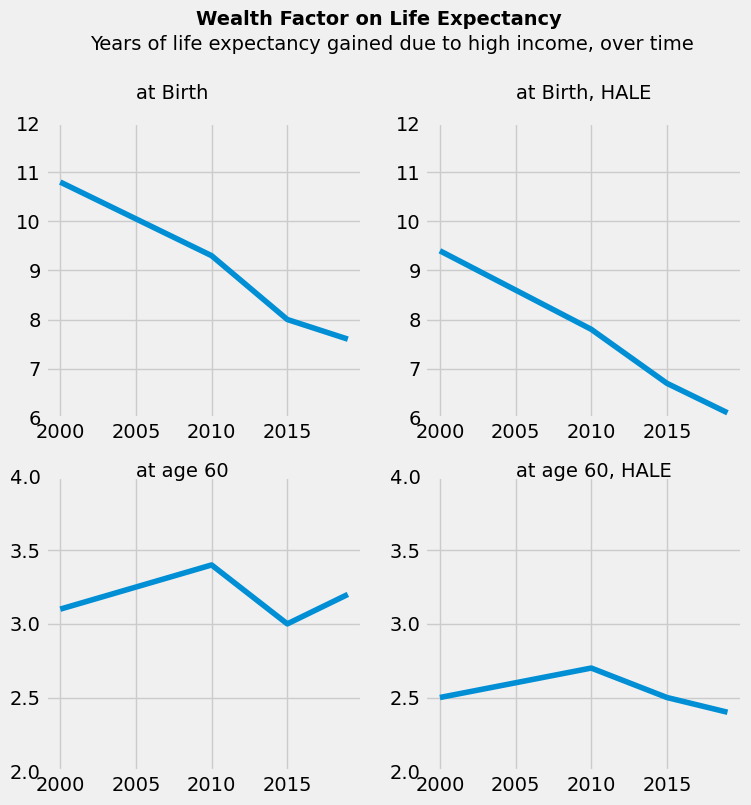

```python
# Exploring Wealth Factor on Life Expectancy over Time

plt.figure(figsize=(8,8))
ax1 = plt.subplot(2,2,1)
ax2 = plt.subplot(2,2,2)
ax3 = plt.subplot(2,2,3)
ax4 = plt.subplot(2,2,4)

ax1.text(2009,14,weight='bold',s='Wealth Factor on Life Expectancy')
ax1.text(2002,13.5,s='Years of life expectancy gained due to high income, over time')

ax1.plot(wealth_data_birth['Year'],wealth_data_birth['wealth_factor'])
ax1.set_ylim(6,12)
ax1.text(2005,12.5,s='at Birth')

ax2.plot(wealth_data_birth_hale['Year'],wealth_data_birth_hale['wealth_factor'])
ax2.set_ylim(6,12)
ax2.text(2005,12.5,s='at Birth, HALE')

ax3.plot(wealth_data_60['Year'],wealth_data_60['wealth_factor'])
ax3.set_ylim(2.0,4.0)
ax3.text(2005,4,s='at age 60')

ax4.plot(wealth_data_60_hale['Year'],wealth_data_60_hale['wealth_factor'])
ax4.set_ylim(2.0,4.0)
ax4.text(2005,4,s='at age 60, HALE')

plt.show()
```

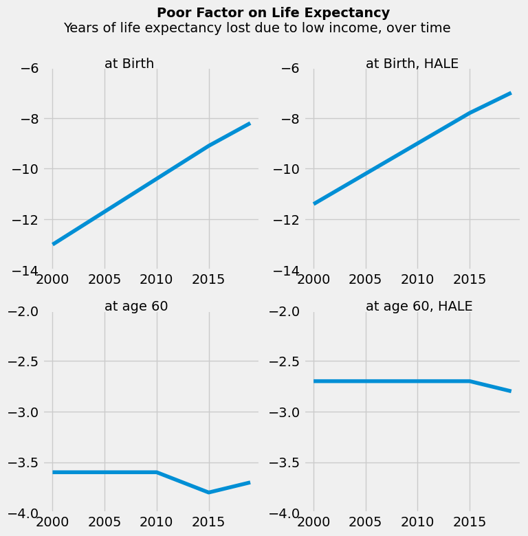

```python
# Exploring Poor Factor on Life Expectancy over Time

plt.figure(figsize=(8,8))

ax1 = plt.subplot(2,2,1)
ax2 = plt.subplot(2,2,2)
ax3 = plt.subplot(2,2,3)
ax4 = plt.subplot(2,2,4)

ax1.text(2010,-4,weight='bold',s='Poor Factor on Life Expectancy')
ax1.text(2001,-4.6,s='Years of life expectancy lost due to low income, over time ')

ax1.plot(wealth_data_birth['Year'],wealth_data_birth['poor_factor'])
ax1.set_ylim(-14,-6)
ax1.text(2005,-6,s='at Birth')

ax2.plot(wealth_data_birth_hale['Year'],wealth_data_birth_hale['poor_factor'])
ax2.set_ylim(-14,-6)
ax2.text(2005,-6,s='at Birth, HALE')

ax3.plot(wealth_data_60['Year'],wealth_data_60['poor_factor'])
ax3.set_ylim(-4,-2)
ax3.text(2005,-2,s='at age 60')

ax4.plot(wealth_data_60_hale['Year'],wealth_data_60_hale['poor_factor'])
ax4.set_ylim(-4,-2)
ax4.text(2005,-2,s='at age 60, HALE')

plt.show()
```

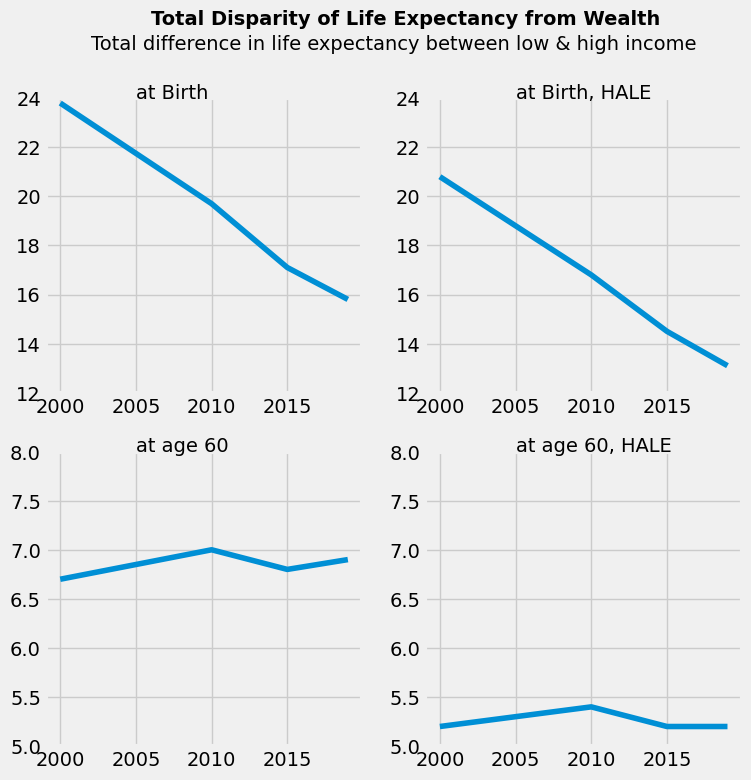

```python
# Exploring Total Difference in Life Expectancy for High Vs. Low Income over Time

plt.figure(figsize=(8,8))
ax1 = plt.subplot(2,2,1)
ax2 = plt.subplot(2,2,2)
ax3 = plt.subplot(2,2,3)
ax4 = plt.subplot(2,2,4)

ax1.text(2006,27,weight='bold',s='Total Disparity of Life Expectancy from Wealth')
ax1.text(2002,26,s='Total difference in life expectancy between low & high income')

ax1.plot(wealth_data_birth['Year'],wealth_data_birth['total_spread'])
ax1.set_ylim(12,24)
ax1.text(2005,24,s='at Birth')

ax2.plot(wealth_data_birth_hale['Year'],wealth_data_birth_hale['total_spread'])
ax2.set_ylim(12,24)
ax2.text(2005,24,s='at Birth, HALE')

ax3.plot(wealth_data_60['Year'],wealth_data_60['total_spread'])
ax3.set_ylim(5,8)
ax3.text(2005,8,s='at age 60')

ax4.plot(wealth_data_60_hale['Year'],wealth_data_60_hale['total_spread'])
ax4.set_ylim(5,8)
ax4.text(2005,8,s='at age 60, HALE')

plt.show()
```

## Income Life Expectancy Gap is Decreasing

Based on these graphs, it seems that life expectancy disparity due to wealth has been decreasing for at Birth. For "at Age 60", life expectancy has essentially remained flat. Let's focus on life expectancy at birth, and generate different graphs that display our findings in a clear way.

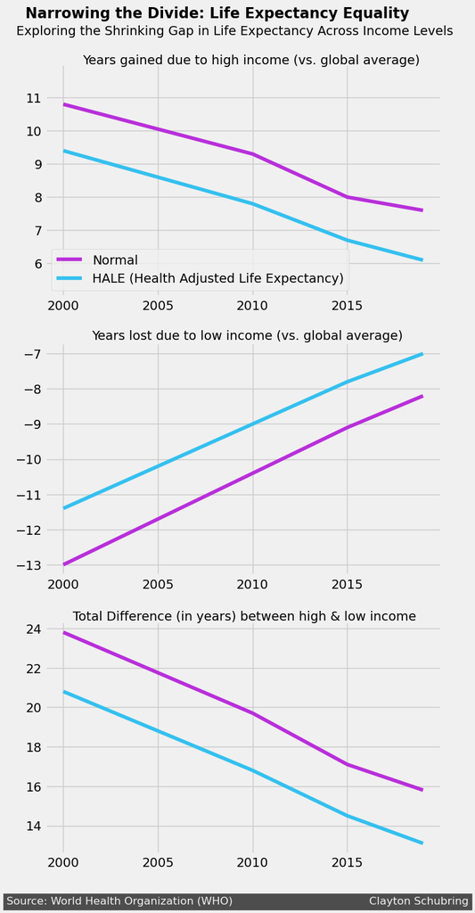

```python
# Narrowing the Divide - HALE

plt.figure(figsize=(7,15))
ax1=plt.subplot(3,1,1)

ax1.text(1997.5,12.9,s='Exploring the Shrinking Gap in Life Expectancy Across Income Levels')
ax1.text(2001,12,s='Years gained due to high income (vs. global average)')

ax1.plot(wealth_data_birth['Year'],wealth_data_birth['wealth_factor'],color='#b82fda',label='Normal')
ax1.plot(wealth_data_birth_hale['Year'],wealth_data_birth_hale['wealth_factor'], color='#34c0ef', label='HALE (Health Adjusted Life Expectancy)')
ax1.text(1998,13.4,s='Narrowing the Divide: Life Expectancy Equality',weight='bold',fontsize=16)
ax1.set_xticks([2000,2005,2010,2015])
ax1.set_yticks([6,7,8,9,10,11])
ax1.set_ylim(5,12)
ax1.legend(loc='lower left')

ax2=plt.subplot(3,1,2)
ax2.plot(wealth_data_birth['Year'],wealth_data_birth['poor_factor'],color='#b82fda',label='Normal')
ax2.plot(wealth_data_birth_hale['Year'],wealth_data_birth_hale['poor_factor'], color='#34c0ef', label='HALE')
ax2.text(2001.5,-6.6,s='Years lost due to low income (vs. global average)')
ax2.set_xticks([2000,2005,2010,2015])

ax3=plt.subplot(3,1,3)
ax3.plot(wealth_data_birth['Year'],wealth_data_birth['total_spread'],color='#b82fda',label='Normal')
ax3.plot(wealth_data_birth_hale['Year'],wealth_data_birth_hale['total_spread'], color='#34c0ef', label='HALE')
ax3.text(2000.5,24.4,s='Total Difference (in years) between high & low income')
ax3.set_xticks([2000,2005,2010,2015])

ax3.text(1997,10,
        'Source: World Health Organization (WHO)' + ' '*40 + 'Clayton Schubring',
        color = '#f0f0f0',
        backgroundcolor = '#4d4d4d',
        size=12)

plt.show()
```

```python
# Calculating the wealth/poor/difference factors for each gender

wealth_data_birth_male = pd.DataFrame(data={'Year': years})

for year in years:

        data = income_expectancy[income_expectancy['Year'] == year]

        high_income = data[data['World Bank income group'] == 'High-income']
        high_val = high_income['Life expectancy at birth (years)  Male'].astype(float).iloc[0]

        low_income = data[data['World Bank income group'] == 'Low-income']
        low_val = low_income['Life expectancy at birth (years)  Male'].astype(float).iloc[0]

        global_income = data[data['World Bank income group'] == 'Global']
        global_val = global_income['Life expectancy at birth (years)  Male'].astype(float).iloc[0]

        wealth_factor = high_val - global_val
        poor_factor = low_val - global_val
        total_spread = high_val - low_val

        wealth_data_birth_male.loc[wealth_data_birth_male['Year'] == year, 'wealth_factor'] = wealth_factor
        wealth_data_birth_male.loc[wealth_data_birth_male['Year'] == year, 'poor_factor'] = poor_factor
        wealth_data_birth_male.loc[wealth_data_birth_male['Year'] == year, 'total_spread'] = total_spread


wealth_data_birth_female = pd.DataFrame(data={'Year': years})

for year in years:

        data = income_expectancy[income_expectancy['Year'] == year]

        high_income = data[data['World Bank income group'] == 'High-income']
        high_val = high_income['Life expectancy at birth (years)  Female'].astype(float).iloc[0]

        low_income = data[data['World Bank income group'] == 'Low-income']
        low_val = low_income['Life expectancy at birth (years)  Female'].astype(float).iloc[0]

        global_income = data[data['World Bank income group'] == 'Global']
        global_val = global_income['Life expectancy at birth (years)  Female'].astype(float).iloc[0]

        wealth_factor = high_val - global_val
        poor_factor = low_val - global_val
        total_spread = high_val - low_val

        wealth_data_birth_female.loc[wealth_data_birth_female['Year'] == year, 'wealth_factor'] = wealth_factor
        wealth_data_birth_female.loc[wealth_data_birth_female['Year'] == year, 'poor_factor'] = poor_factor
        wealth_data_birth_female.loc[wealth_data_birth_female['Year'] == year, 'total_spread'] = total_spread
```

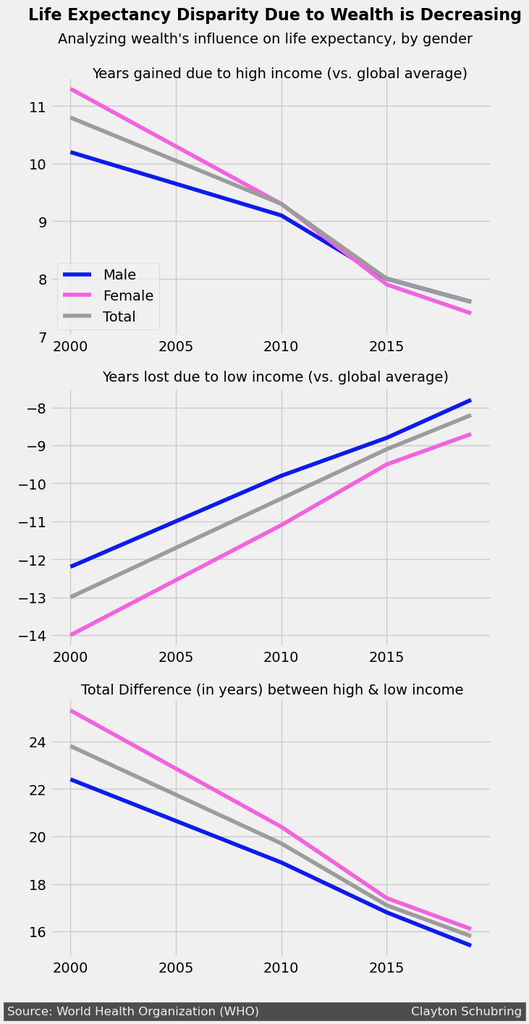

```python
# Income Life Expectancy Gap, by Gender

plt.figure(figsize=(7,15))

ax1=plt.subplot(3,1,1)
ax1.plot(wealth_data_birth_male['Year'],wealth_data_birth_male['wealth_factor'], color='#0c1bed', label='Male')
ax1.plot(wealth_data_birth_female['Year'],wealth_data_birth_female['wealth_factor'], color='#f263df', label='Female')
ax1.plot(wealth_data_birth['Year'],wealth_data_birth['wealth_factor'],color='#9c9c9c',label='Total')
ax1.text(1998,12.5,s='Life Expectancy Disparity Due to Wealth is Decreasing',weight='bold',fontsize=16)
ax1.text(1999.4,12.1,s='Analyzing wealth\'s influence on life expectancy, by gender')
ax1.text(2001,11.5,s='Years gained due to high income (vs. global average)')
ax1.legend(loc='lower left')
ax1.set_xticks([2000,2005,2010,2015])
ax1.set_yticks([7,8,9,10,11])

ax2=plt.subplot(3,1,2)
ax2.plot(wealth_data_birth['Year'],wealth_data_birth['poor_factor'],color='#9c9c9c',label='Total')
ax2.plot(wealth_data_birth_male['Year'],wealth_data_birth_male['poor_factor'], color='#0c1bed', label='Male')
ax2.plot(wealth_data_birth_female['Year'],wealth_data_birth_female['poor_factor'], color='#f263df', label='Female')
ax2.text(2001.5,-7.3,s='Years lost due to low income (vs. global average)')
ax2.set_xticks([2000,2005,2010,2015])

ax3=plt.subplot(3,1,3)
ax3.plot(wealth_data_birth['Year'],wealth_data_birth['total_spread'],color='#9c9c9c',label='Total')
ax3.plot(wealth_data_birth_male['Year'],wealth_data_birth_male['total_spread'], color='#0c1bed', label='Male')
ax3.plot(wealth_data_birth_female['Year'],wealth_data_birth_female['total_spread'], color='#f263df', label='Female')
ax3.text(2000.5,26,s='Total Difference (in years) between high & low income')
ax3.set_xticks([2000,2005,2010,2015])

ax3.text(1997,12.5,
        'Source: World Health Organization (WHO)' + ' '*40 + 'Clayton Schubring',
        color = '#f0f0f0',
        backgroundcolor = '#4d4d4d',
        size=12)

plt.show()
```

## Narrowing the Divide

Let's now combine all of these graphs on a single plot, and use more design techniques to improve the data-ink ratio & readability.

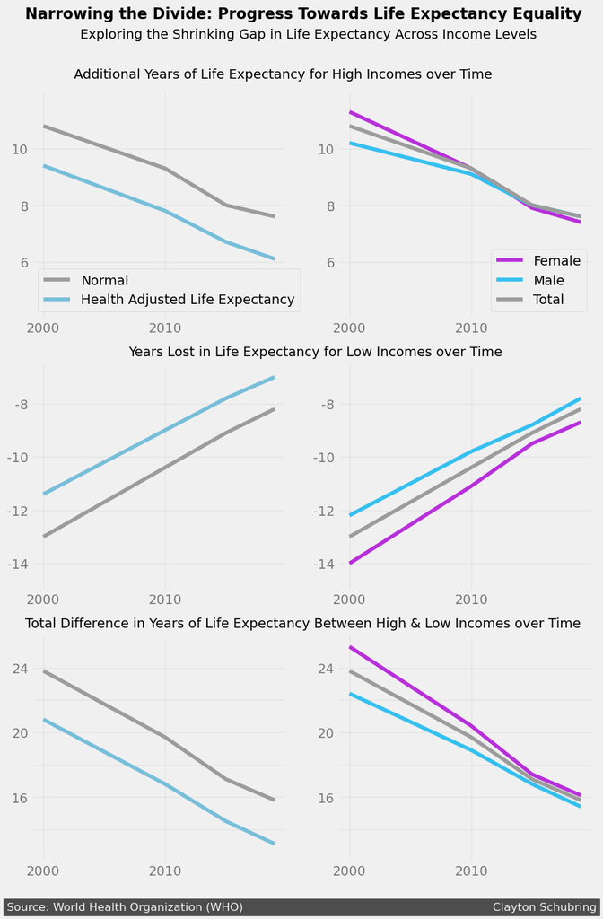

```python
# Generating the figure
plt.figure(figsize=(9.5,14))
ax1=plt.subplot(3,2,1)
ax2=plt.subplot(3,2,2)
ax3=plt.subplot(3,2,3)
ax4=plt.subplot(3,2,4)
ax5=plt.subplot(3,2,5)
ax6=plt.subplot(3,2,6)

# Title
ax1.text(1998.5,14.6,s='Narrowing the Divide: Progress Towards Life Expectancy Equality',weight='bold',fontsize=16)
ax1.text(2003,13.9,s='Exploring the Shrinking Gap in Life Expectancy Across Income Levels')

# ax1: Wealth factor, hale
ax1.text(2002.5,12.5,s='Additional Years of Life Expectancy for High Incomes over Time')
ax1.plot(wealth_data_birth['Year'],wealth_data_birth['wealth_factor'],color='#9c9c9c',label='Normal')
ax1.plot(wealth_data_birth_hale['Year'],wealth_data_birth_hale['wealth_factor'], color='#77beda', label='Health Adjusted Life Expectancy')
ax1.legend(loc='lower left')
ax1.set_xticks([2000,2010,2020])
ax1.set_yticks([4,6,8,10])
ax1.set_xticklabels([2000,2010,''], alpha=0.5)
ax1.set_yticklabels(['',6,8,10], alpha=0.5)
ax1.set_ylim(4,12)
ax1.grid(alpha=0.3)

# ax2: Wealth factor, gender
ax2.plot(wealth_data_birth_female['Year'],wealth_data_birth_female['wealth_factor'], color='#b82fda', label='Female')
ax2.plot(wealth_data_birth_male['Year'],wealth_data_birth_male['wealth_factor'], color='#34c0ef', label='Male')
ax2.plot(wealth_data_birth['Year'],wealth_data_birth['wealth_factor'],color='#9c9c9c',label='Total')
ax2.legend(loc='lower right')
ax2.set_xticks([2000,2010,2020])
ax2.set_yticks([4,6,8,10])
ax2.set_xticklabels([2000,2010,''], alpha=0.5)
ax2.set_yticklabels(['',6,8,10], alpha=0.5)
ax2.set_ylim(4,12)
ax2.grid(alpha=0.3)

# ax3: Poor factor, hale
ax3.text(2007,-6.2,s='Years Lost in Life Expectancy for Low Incomes over Time')
ax3.plot(wealth_data_birth['Year'],wealth_data_birth['poor_factor'],color='#9c9c9c',label='Normal')
ax3.plot(wealth_data_birth_hale['Year'],wealth_data_birth_hale['poor_factor'], color='#77beda', label='HALE')
ax3.set_xticks([2000,2010,2020])
ax3.set_xticklabels([2000,2010,''], alpha=0.5)
ax3.set_yticks([-14,-12,-10,-8])
ax3.set_yticklabels([-14,-12,-10,-8], alpha=0.5)
ax3.set_ylim(-15,-6.5)
ax3.grid(alpha=0.3)

# ax4: Poor factor, gender
ax4.plot(wealth_data_birth_female['Year'],wealth_data_birth_female['poor_factor'], color='#b82fda', label='Female')
ax4.plot(wealth_data_birth_male['Year'],wealth_data_birth_male['poor_factor'], color='#34c0ef', label='Male')
ax4.plot(wealth_data_birth['Year'],wealth_data_birth['poor_factor'],color='#9c9c9c',label='Total')
ax4.set_xticks([2000,2010,2020])
ax4.set_xticklabels([2000,2010,''], alpha=0.5)
ax4.set_yticks([-14,-12,-10,-8])
ax4.set_yticklabels([-14,-12,-10,-8], alpha=0.5)
ax4.set_ylim(-15,-6.5)
ax4.grid(alpha=0.3)

# ax5: Total spread, hale
ax5.text(1998.5,26.5,s='Total Difference in Years of Life Expectancy Between High & Low Incomes over Time')
ax5.plot(wealth_data_birth['Year'],wealth_data_birth['total_spread'],color='#9c9c9c',label='Normal')
ax5.plot(wealth_data_birth_hale['Year'],wealth_data_birth_hale['total_spread'], color='#77beda', label='HALE')
ax5.set_xticks([2000,2010,2020])
ax5.set_xticklabels([2000,2010,''], alpha=0.5)
ax5.set_ylim(12,26)
ax5.set_yticks([14,16,18,20,22,24])
ax5.set_yticklabels(['',16,'',20,'',24], alpha=0.5)
ax5.grid(alpha=0.3)

# ax6: Total spread, gender
ax6.plot(wealth_data_birth['Year'],wealth_data_birth['total_spread'],color='#9c9c9c',label='Total')
ax6.plot(wealth_data_birth_male['Year'],wealth_data_birth_male['total_spread'], color='#34c0ef', label='Male')
ax6.plot(wealth_data_birth_female['Year'],wealth_data_birth_female['total_spread'], color='#b82fda', label='Female')
ax6.set_xticks([2000,2010,2020])
ax6.set_xticklabels([2000,2010,''], alpha=0.5)
ax6.set_ylim(12,26)
ax6.set_yticks([14,16,18,20,22,24])
ax6.set_yticklabels(['',16,'',20,'',24], alpha=0.5)
ax6.grid(alpha=0.3)

# Signature
ax5.text(1997,9,
        'Source: World Health Organization (WHO)' + ' '*70 + 'Clayton Schubring',
        color = '#f0f0f0',
        backgroundcolor = '#4d4d4d',
        size=12)


plt.show()
```

# Part 2: By Gender

Let's explore the "gender gap" in life expectancy. Is the male and female life expectancy gap increasing or decreasing over time? Is it greater or less in certain regions? First, we will examine by income group, then by country.

```python
income_expectancy.head()
```

|  | World Bank income group | Year | Life expectancy at birth (years) Both sexes | Life expectancy at birth (years) Male | Life expectancy at birth (years) Female | Life expectancy at age 60 (years) Both sexes | Life expectancy at age 60 (years) Male | Life expectancy at age 60 (years) Female | Healthy life expectancy (HALE) at birth (years) Both sexes | Healthy life expectancy (HALE) at birth (years) Male | Healthy life expectancy (HALE) at birth (years) Female | Healthy life expectancy (HALE) at age 60 (years) Both sexes | Healthy life expectancy (HALE) at age 60 (years) Male | Healthy life expectancy (HALE) at age 60 (years) Female |
| --- | --- | --- | --- | --- | --- | --- | --- | --- | --- | --- | --- | --- | --- | --- |
| 0 | Global | 2019 | 73.3 | 70.8 | 75.9 | 21.1 | 19.5 | 22.7 | 63.7 | 62.5 | 64.9 | 15.8 | 14.8 | 16.6 |
| 1 | Global | 2015 | 72.3 | 69.8 | 74.9 | 20.8 | 19.1 | 22.3 | 62.9 | 61.7 | 64.2 | 15.5 | 14.6 | 16.4 |
| 2 | Global | 2010 | 70.5 | 68.0 | 73.2 | 20.1 | 18.4 | 21.7 | 61.5 | 60.2 | 62.9 | 15.1 | 14.1 | 16.1 |
| 3 | Global | 2000 | 66.8 | 64.4 | 69.3 | 18.8 | 17.2 | 20.4 | 58.3 | 57.1 | 59.6 | 14.1 | 13.1 | 15.1 |
| 4 | Low-income | 2019 | 65.1 | 63.0 | 67.2 | 17.4 | 16.2 | 18.5 | 56.7 | 55.7 | 57.7 | 13.0 | 12.3 | 13.7 |

```python
# Calculating the Gender Gap
income_expectancy['Gender Gap: at Birth'] = income_expectancy['Life expectancy at birth (years)  Female'] - income_expectancy['Life expectancy at birth (years)  Male']
income_expectancy['Gender Gap: at 60'] = income_expectancy['Life expectancy at age 60 (years)  Female'] - income_expectancy['Life expectancy at age 60 (years)  Male']
```

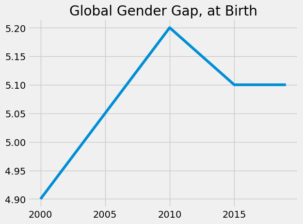

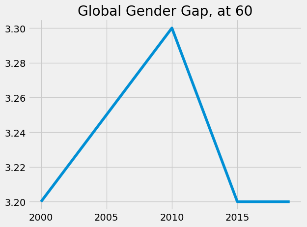

```python
# Exploring the Gender Gap, Global
global_vals = income_expectancy[income_expectancy['World Bank income group'] == ('Global')]

plt.plot(global_vals['Year'], global_vals['Gender Gap: at Birth'])
plt.title("Global Gender Gap, at Birth")
plt.xticks([2000,2005,2010,2015])
plt.show()

plt.plot(global_vals['Year'], global_vals['Gender Gap: at 60'])
plt.title("Global Gender Gap, at 60")
plt.xticks([2000,2005,2010,2015])
plt.show()
```

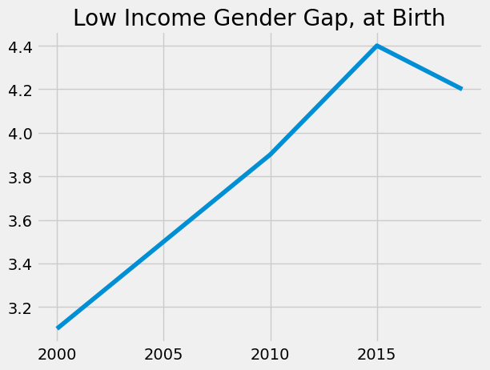

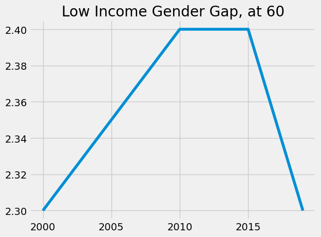

```python
# Exploring the Gender Gap, Low Income
low_vals = income_expectancy[income_expectancy['World Bank income group'] == ('Low-income')]

plt.plot(low_vals['Year'], low_vals['Gender Gap: at Birth'])
plt.title("Low Income Gender Gap, at Birth")
plt.xticks([2000,2005,2010,2015])
plt.show()

plt.plot(low_vals['Year'], low_vals['Gender Gap: at 60'])
plt.title("Low Income Gender Gap, at 60")
plt.xticks([2000,2005,2010,2015])
plt.show()
```

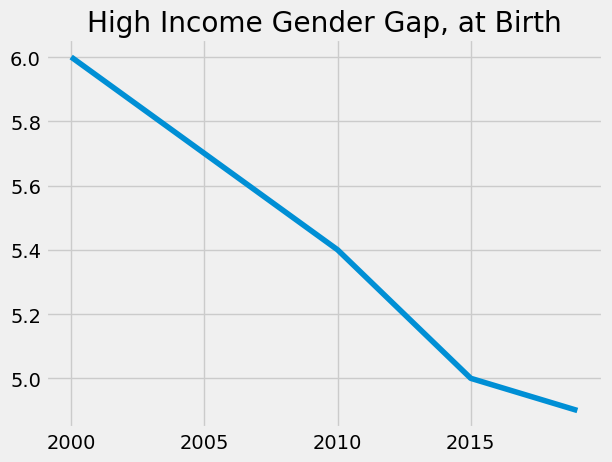

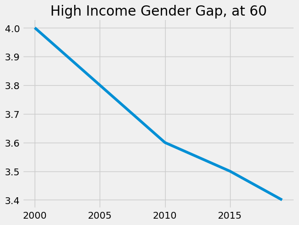

```python
# Exploring the Gender Gap, High Income
high_vals = income_expectancy[income_expectancy['World Bank income group'] == ('High-income')]

plt.plot(high_vals['Year'], high_vals['Gender Gap: at Birth'])
plt.title("High Income Gender Gap, at Birth")
plt.xticks([2000,2005,2010,2015])
plt.show()

plt.plot(high_vals['Year'], high_vals['Gender Gap: at 60'])
plt.title("High Income Gender Gap, at 60")
plt.xticks([2000,2005,2010,2015])
plt.show()
```

## Gender Gap and Income Level

It seems that the gender gap in life expectancy is decreasing for high income groups; however, it is increasing for low income and global groups.

There doesn't seem to be a clear trend; even the movement we've observed is often very small. Let's graph each (at birth, at 60) for all 5 income groups and see if there is a clear trend. Perhaps the gender life expectancy gap is converging?

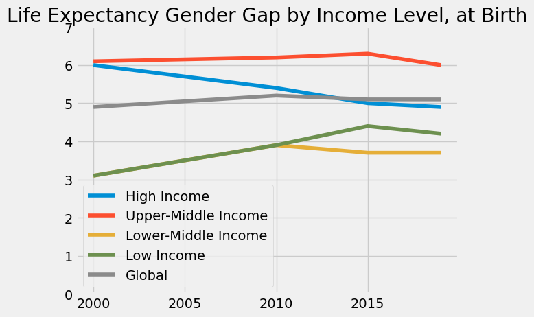

```python
# Exploring the Gender Gap by Each Income Level, at Birth
upper_mid_vals = income_expectancy[income_expectancy['World Bank income group'] == ('Upper-middle-income')]
lower_mid_vals = income_expectancy[income_expectancy['World Bank income group'] == ('Lower-middle-income')]

plt.plot(high_vals['Year'], high_vals['Gender Gap: at Birth'], label="High Income")
plt.plot(upper_mid_vals['Year'], upper_mid_vals['Gender Gap: at Birth'], label="Upper-Middle Income")
plt.plot(lower_mid_vals['Year'], lower_mid_vals['Gender Gap: at Birth'], label="Lower-Middle Income")
plt.plot(low_vals['Year'], low_vals['Gender Gap: at Birth'], label="Low Income")
plt.plot(global_vals['Year'], global_vals['Gender Gap: at Birth'], label="Global")
plt.title("Life Expectancy Gender Gap by Income Level, at Birth")

plt.ylim(0,7)
plt.xticks([2000,2005,2010,2015])
plt.legend(loc='lower left')
plt.show()
```

## Average Gender Gap by Year

This graph doesn't reveal much. It seems there is no clear trend over time in the gender gap, when looking by income level. Let's pivot and find the average gender gap for each year, and use that to see if there is a trend.

```python
# Calculating the Average Gender Gap, at Birth
avg_gender_gap = pd.DataFrame()
avg_gender_gap['Year'] = years
gender_gap_avgs = []

for year in years:
    current_vals = income_expectancy[income_expectancy["Year"] == year]
    avg = current_vals["Gender Gap: at Birth"].mean()
    gender_gap_avgs.append(avg)

avg_gender_gap["Avg Gender Gap: at Birth"] = gender_gap_avgs
avg_gender_gap
```

|  | Year | Avg Gender Gap: at Birth |
| --- | --- | --- |
| 0 | 2000 | 4.64 |
| 1 | 2010 | 4.92 |
| 2 | 2015 | 4.90 |
| 3 | 2019 | 4.78 |

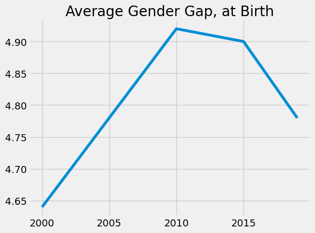

```python
# Exploring the Average Gender Gap, at Birth
plt.plot(avg_gender_gap["Year"], avg_gender_gap["Avg Gender Gap: at Birth"])
plt.title("Average Gender Gap, at Birth")
plt.xticks([2000,2005,2010,2015])
plt.show()
```

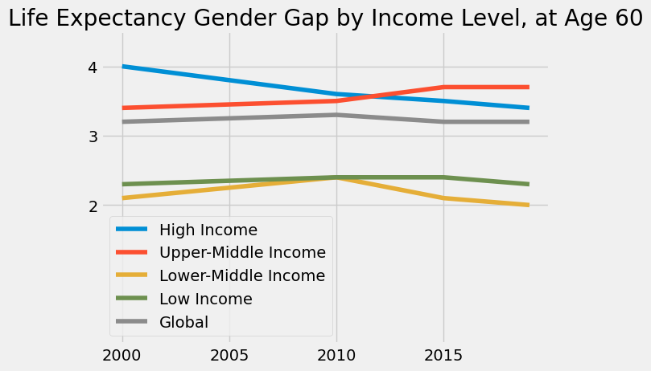

```python
# Exploring the Gender Gap by Each Income Level, at Age 60
plt.plot(high_vals['Year'], high_vals['Gender Gap: at 60'], label="High Income")
plt.plot(upper_mid_vals['Year'], upper_mid_vals['Gender Gap: at 60'], label="Upper-Middle Income")
plt.plot(lower_mid_vals['Year'], lower_mid_vals['Gender Gap: at 60'], label="Lower-Middle Income")
plt.plot(low_vals['Year'], low_vals['Gender Gap: at 60'], label="Low Income")
plt.plot(global_vals['Year'], global_vals['Gender Gap: at 60'], label="Global")
plt.title("Life Expectancy Gender Gap by Income Level, at Age 60")
plt.ylim(0,4.5)
plt.yticks([2,3,4])
plt.xticks([2000,2005,2010,2015])
plt.legend(loc='lower left')
plt.show()
```

```python
# Calculating the Average Gender Gap, at Age 60
gender_gap_avgs_60 = []
for year in years:
    current_vals_60 = income_expectancy[income_expectancy["Year"] == year]
    avg_60 = current_vals_60["Gender Gap: at 60"].mean()
    gender_gap_avgs_60.append(avg_60)

avg_gender_gap["Avg Gender Gap: at 60"] = gender_gap_avgs_60
avg_gender_gap
```

|  | Year | Avg Gender Gap: at Birth | Avg Gender Gap: at 60 |
| --- | --- | --- | --- |
| 0 | 2000 | 4.64 | 3.00 |
| 1 | 2010 | 4.92 | 3.04 |
| 2 | 2015 | 4.90 | 2.98 |
| 3 | 2019 | 4.78 | 2.92 |

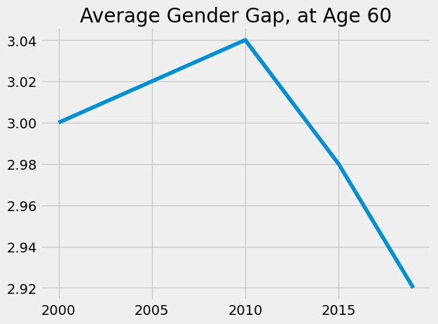

```python
# Exploring the Average Gender Gap, at Age 60
plt.plot(avg_gender_gap["Year"], avg_gender_gap["Avg Gender Gap: at 60"])
plt.title("Average Gender Gap, at Age 60")
plt.xticks([2000,2005,2010,2015])
plt.show()
```

## Gender Gap and Income - Conclusion

In conclusion, there doesn't seem to be any discernable or noteworthy trends with relation to the gender life expectancy gap. This gap has stayed roughly flat on average, and while it has made some small movements for specific income groups, there's nothing for us to further analyze. Women simply live longer than men, and this seems to remain true as time progresses.

Lets proceed to the next section of our analysis, where we will surely find some interesting results: life expectancy analysis by country.

## Gender Gap Analysis by Country

```python
# Calculating the gender gap by country
country_gender_gap = country_expectancy.copy()
country_gender_gap['Gender Gap: at Birth'] = country_gender_gap['Life expectancy at birth (years)  Female'] - country_gender_gap['Life expectancy at birth (years)  Male']
country_gender_gap['Gender Gap: at 60'] = country_gender_gap['Life expectancy at age 60 (years)  Female'] - country_gender_gap['Life expectancy at age 60 (years)  Male']
```

```python
country_gender_gap.head()
```

|  | Countries, territories and areas | Year | Life expectancy at birth (years) Both sexes | Life expectancy at birth (years) Male | Life expectancy at birth (years) Female | Life expectancy at age 60 (years) Both sexes | Life expectancy at age 60 (years) Male | Life expectancy at age 60 (years) Female | Healthy life expectancy (HALE) at birth (years) Both sexes | Healthy life expectancy (HALE) at birth (years) Male | Healthy life expectancy (HALE) at birth (years) Female | Healthy life expectancy (HALE) at age 60 (years) Both sexes | Healthy life expectancy (HALE) at age 60 (years) Male | Healthy life expectancy (HALE) at age 60 (years) Female | Gender Gap: at Birth | Gender Gap: at 60 |
| --- | --- | --- | --- | --- | --- | --- | --- | --- | --- | --- | --- | --- | --- | --- | --- | --- |
| 0 | Afghanistan | 2019 | 63.2 | 63.3 | 63.2 | 15.2 | 15.4 | 15.1 | 53.9 | 54.7 | 53.2 | 10.8 | 11.2 | 10.6 | -0.1 | -0.3 |
| 1 | Afghanistan | 2015 | 61.7 | 61.0 | 62.3 | 15.6 | 15.7 | 15.5 | 52.6 | 52.8 | 52.4 | 11.2 | 11.5 | 10.9 | 1.3 | -0.2 |
| 2 | Afghanistan | 2010 | 59.9 | 59.6 | 60.3 | 15.1 | 15.1 | 15.2 | 51.1 | 51.5 | 50.7 | 10.9 | 11.1 | 10.7 | 0.7 | 0.1 |
| 3 | Afghanistan | 2000 | 55.0 | 54.6 | 55.4 | 13.9 | 13.6 | 14.2 | 46.8 | 46.9 | 46.6 | 10.2 | 10.2 | 10.1 | 0.8 | 0.6 |
| 4 | Albania | 2019 | 78.0 | 76.3 | 79.9 | 21.0 | 20.2 | 21.9 | 69.1 | 68.0 | 70.3 | 16.6 | 15.9 | 17.3 | 3.6 | 1.7 |

```python
top_20_gender_gap = country_gender_gap.nlargest(20,"Gender Gap: at Birth")

top_20_gender_gap_countries = []
for country in top_20_gender_gap["Countries, territories and areas"]:
    top_20_gender_gap_countries.append(country)
```

```python
bottom_20_gender_gap = country_gender_gap.nsmallest(20,"Gender Gap: at Birth")

bottom_20_gender_gap_countries = []
for country in bottom_20_gender_gap["Countries, territories and areas"]:
    bottom_20_gender_gap_countries.append(country)
```

```python
print("Highest Gender Gap (Top 20)")
for idx, country in enumerate(top_20_gender_gap_countries):
    print(f'{idx}'+ ": " + f'{country}')
```

```
Highest Gender Gap (Top 20)
0: Russian Federation
1: Belarus
2: Russian Federation
3: Kazakhstan
4: Belarus
5: Lithuania
6: Ukraine
7: Latvia
8: Russian Federation
9: Estonia
10: Lithuania
11: Lithuania
12: Belarus
13: Latvia
14: El Salvador
15: Belarus
16: Ukraine
17: Eswatini
18: Kazakhstan
19: Russian Federation
```

```python
print("Lowest Gender Gap (Bottom 20)")
for idx, country in enumerate(bottom_20_gender_gap_countries):
    print(f'{idx}'+ ": " + f'{country}')
```

```
Lowest Gender Gap (Bottom 20)
0: Qatar
1: Qatar
2: Qatar
3: Equatorial Guinea
4: Jordan
5: Congo
6: Afghanistan
7: Mali
8: Haiti
9: Mauritania
10: Mauritania
11: Mauritania
12: Mauritania
13: Qatar
14: Afghanistan
15: Afghanistan
16: Mali
17: Congo
18: Haiti
19: Mali
```

## Best and Worst Countries

I. The worst countries to be a male are Russia, Belarus, Lithuania, Ukraine. Perhaps this is common amongst all Eastern European countries?

II. The best countries to be a male, is Qatar, the only country where males seem to consistently have a longer life expectancy (except in 2000). Mali, Mauritania, Haiti, Congo, and Afganistan also seem to rate high on this list.

```python
# Get the Gender Gap for All Eastern European Countries
eastern_european_countries = ['Latvia', 'Czechia', 'Estonia', 'Lithuania', 'Slovakia', 'Poland',
                               'Romania', 'Bulgaria','Hungary','Belarus', 'Ukraine', 'Russian Federation']
eastern_european_expectancy = country_gender_gap[country_gender_gap["Countries, territories and areas"].isin(eastern_european_countries)]
eastern_european_expectancy = eastern_european_expectancy.sort_values("Life expectancy at birth (years)  Male", ascending=False)
```

```python
eastern_european_gender_gap = eastern_european_expectancy.copy()
eastern_european_gender_gap["Countries, territories and areas"].value_counts()
```

```
Czechia               4
Slovakia              4
Estonia               4
Poland                4
Hungary               4
Romania               4
Bulgaria              4
Lithuania             4
Latvia                4
Belarus               4
Russian Federation    4
Ukraine               4
Name: Countries, territories and areas, dtype: int64
```

```python
# Sorting and Organizing Eastern European Gender Gap Data
eastern_european_gender_gap = eastern_european_gender_gap.sort_values("Year", ascending=False)
eastern_european_gender_gap = eastern_european_gender_gap.drop_duplicates("Countries, territories and areas", keep="first")
eastern_european_gender_gap = eastern_european_gender_gap.sort_values("Life expectancy at birth (years)  Male", ascending=False)
```

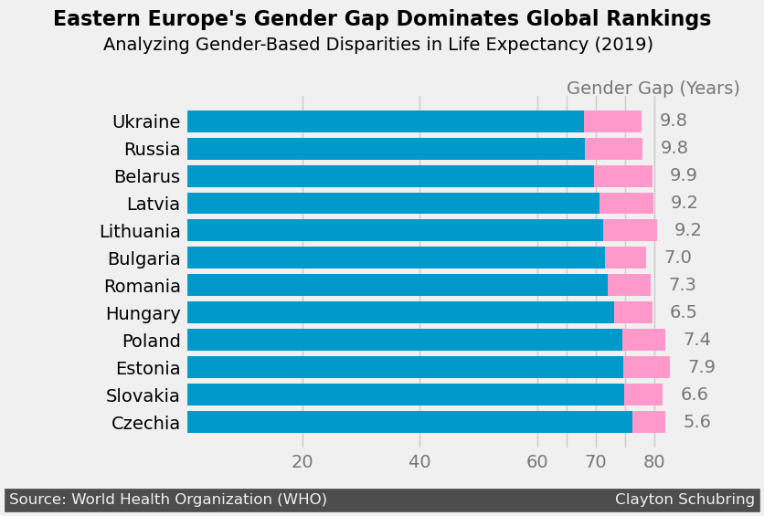

```python
# Fig 2.2 Eastern European Gender Gap

# Generating the Figure
fig, ax = plt.subplots()


for idx, country in enumerate(eastern_european_gender_gap["Countries, territories and areas"]):

    country_data = eastern_european_gender_gap[eastern_european_gender_gap["Countries, territories and areas"] == country]

    # Rename Russia
    if country == "Russian Federation":
        country = "Russia"

    female_value = country_data["Life expectancy at birth (years)  Female"]
    male_value = country_data["Life expectancy at birth (years)  Male"]

    # Plot Male and Female Values
    ax.barh(country, female_value,  color="#FF99CC")
    ax.barh(country, male_value,  color="#0099CC")

    # Gender Gap (Years) Annotation
    gender_gap = country_data["Gender Gap: at Birth"].values.astype(float).round(2)
    ax.text(female_value + 3, idx, s=str(gender_gap[0]), va='center', color='black', alpha=0.5)

ax.yaxis.grid(False)
ax.set_xticks([20,40,60,65,70,75,80])
ax.set_xticklabels([20,40,60,"",70,"",80], alpha=0.5)
ax.text(65,12,"Gender Gap (Years)",alpha=0.5)

# Title
ax.text(-22.5,14.5,"Eastern Europe's Gender Gap Dominates Global Rankings", size=16, weight="bold")
ax.text(-14,13.6,"Analyzing Gender-Based Disparities in Life Expectancy (2019)", size=14)

# Signature
ax.text(-30,-3,
        'Source: World Health Organization (WHO)' + ' '*60 + 'Clayton Schubring',
        color = '#f0f0f0',
        backgroundcolor = '#4d4d4d',
        size=12)

plt.show()
```

```python
qatar_data = country_gender_gap[country_gender_gap["Countries, territories and areas"] == "Qatar"]

qatar_data
```

|  | Countries, territories and areas | Year | Life expectancy at birth (years) Both sexes | Life expectancy at birth (years) Male | Life expectancy at birth (years) Female | Life expectancy at age 60 (years) Both sexes | Life expectancy at age 60 (years) Male | Life expectancy at age 60 (years) Female | Healthy life expectancy (HALE) at birth (years) Both sexes | Healthy life expectancy (HALE) at birth (years) Male | Healthy life expectancy (HALE) at birth (years) Female | Healthy life expectancy (HALE) at age 60 (years) Both sexes | Healthy life expectancy (HALE) at age 60 (years) Male | Healthy life expectancy (HALE) at age 60 (years) Female | Gender Gap: at Birth | Gender Gap: at 60 |
| --- | --- | --- | --- | --- | --- | --- | --- | --- | --- | --- | --- | --- | --- | --- | --- | --- |
| 520 | Qatar | 2019 | 77.2 | 78.0 | 76.6 | 19.5 | 20.6 | 18.4 | 67.1 | 68.1 | 65.1 | 14.2 | 15.1 | 13.1 | -1.4 | -2.2 |
| 521 | Qatar | 2015 | 76.4 | 77.2 | 75.9 | 19.0 | 20.1 | 17.9 | 66.4 | 67.4 | 64.5 | 13.8 | 14.6 | 12.7 | -1.3 | -2.2 |
| 522 | Qatar | 2010 | 74.1 | 75.0 | 73.9 | 17.3 | 18.7 | 16.1 | 64.7 | 65.8 | 63.1 | 12.5 | 13.6 | 11.5 | -1.1 | -2.6 |
| 523 | Qatar | 2000 | 71.3 | 71.1 | 71.7 | 15.9 | 16.4 | 15.2 | 62.4 | 62.8 | 61.4 | 11.6 | 12.1 | 10.8 | 0.6 | -1.2 |

```python
bottom_20_gender_gap
```

|  | Countries, territories and areas | Year | Life expectancy at birth (years) Both sexes | Life expectancy at birth (years) Male | Life expectancy at birth (years) Female | Life expectancy at age 60 (years) Both sexes | Life expectancy at age 60 (years) Male | Life expectancy at age 60 (years) Female | Healthy life expectancy (HALE) at birth (years) Both sexes | Healthy life expectancy (HALE) at birth (years) Male | Healthy life expectancy (HALE) at birth (years) Female | Healthy life expectancy (HALE) at age 60 (years) Both sexes | Healthy life expectancy (HALE) at age 60 (years) Male | Healthy life expectancy (HALE) at age 60 (years) Female | Gender Gap: at Birth | Gender Gap: at 60 |
| --- | --- | --- | --- | --- | --- | --- | --- | --- | --- | --- | --- | --- | --- | --- | --- | --- |
| 520 | Qatar | 2019 | 77.2 | 78.0 | 76.6 | 19.5 | 20.6 | 18.4 | 67.1 | 68.1 | 65.1 | 14.2 | 15.1 | 13.1 | -1.4 | -2.2 |
| 521 | Qatar | 2015 | 76.4 | 77.2 | 75.9 | 19.0 | 20.1 | 17.9 | 66.4 | 67.4 | 64.5 | 13.8 | 14.6 | 12.7 | -1.3 | -2.2 |
| 522 | Qatar | 2010 | 74.1 | 75.0 | 73.9 | 17.3 | 18.7 | 16.1 | 64.7 | 65.8 | 63.1 | 12.5 | 13.6 | 11.5 | -1.1 | -2.6 |
| 210 | Equatorial Guinea | 2010 | 59.7 | 59.8 | 59.1 | 17.6 | 17.0 | 18.3 | 51.7 | 52.4 | 50.4 | 12.8 | 12.5 | 13.1 | -0.7 | 1.3 |
| 339 | Jordan | 2000 | 72.6 | 73.1 | 72.5 | 18.6 | 19.5 | 17.9 | 63.6 | 65.0 | 62.3 | 13.9 | 14.9 | 13.1 | -0.6 | -1.6 |
| 150 | Congo | 2010 | 61.0 | 61.0 | 60.8 | 15.7 | 15.2 | 16.1 | 53.0 | 53.8 | 52.2 | 11.6 | 11.4 | 11.8 | -0.2 | 0.9 |
| 0 | Afghanistan | 2019 | 63.2 | 63.3 | 63.2 | 15.2 | 15.4 | 15.1 | 53.9 | 54.7 | 53.2 | 10.8 | 11.2 | 10.6 | -0.1 | -0.3 |
| 411 | Mali | 2000 | 52.6 | 52.6 | 52.7 | 16.0 | 16.2 | 15.9 | 45.6 | 46.0 | 45.3 | 11.7 | 11.9 | 11.5 | 0.1 | -0.3 |
| 287 | Haiti | 2000 | 57.0 | 57.0 | 57.2 | 15.8 | 15.6 | 15.9 | 50.0 | 50.5 | 49.6 | 12.1 | 12.1 | 12.2 | 0.2 | 0.3 |
| 419 | Mauritania | 2000 | 62.0 | 61.8 | 62.2 | 17.1 | 17.2 | 17.0 | 54.4 | 54.8 | 54.0 | 12.8 | 13.1 | 12.6 | 0.4 | -0.2 |
| 417 | Mauritania | 2015 | 67.4 | 67.2 | 67.7 | 18.8 | 19.0 | 18.7 | 58.9 | 59.4 | 58.6 | 14.2 | 14.5 | 13.9 | 0.5 | -0.3 |
| 418 | Mauritania | 2010 | 65.6 | 65.4 | 65.9 | 18.5 | 18.7 | 18.3 | 57.4 | 57.9 | 57.1 | 13.9 | 14.3 | 13.6 | 0.5 | -0.4 |
| 416 | Mauritania | 2019 | 68.4 | 68.1 | 68.7 | 19.0 | 19.1 | 18.9 | 59.8 | 60.2 | 59.4 | 14.3 | 14.6 | 14.1 | 0.6 | -0.2 |
| 523 | Qatar | 2000 | 71.3 | 71.1 | 71.7 | 15.9 | 16.4 | 15.2 | 62.4 | 62.8 | 61.4 | 11.6 | 12.1 | 10.8 | 0.6 | -1.2 |
| 2 | Afghanistan | 2010 | 59.9 | 59.6 | 60.3 | 15.1 | 15.1 | 15.2 | 51.1 | 51.5 | 50.7 | 10.9 | 11.1 | 10.7 | 0.7 | 0.1 |
| 3 | Afghanistan | 2000 | 55.0 | 54.6 | 55.4 | 13.9 | 13.6 | 14.2 | 46.8 | 46.9 | 46.6 | 10.2 | 10.2 | 10.1 | 0.8 | 0.6 |
| 410 | Mali | 2010 | 59.0 | 58.6 | 59.5 | 16.8 | 16.7 | 17.0 | 51.3 | 51.6 | 51.1 | 12.3 | 12.3 | 12.3 | 0.9 | 0.3 |
| 149 | Congo | 2015 | 63.1 | 62.6 | 63.6 | 16.1 | 15.5 | 16.6 | 54.9 | 55.3 | 54.5 | 12.0 | 11.8 | 12.2 | 1.0 | 1.1 |
| 285 | Haiti | 2015 | 62.6 | 62.1 | 63.1 | 16.5 | 16.3 | 16.7 | 54.6 | 54.8 | 54.4 | 12.6 | 12.6 | 12.6 | 1.0 | 0.4 |
| 409 | Mali | 2015 | 60.9 | 60.4 | 61.4 | 17.1 | 16.9 | 17.2 | 53.0 | 53.3 | 52.7 | 12.5 | 12.6 | 12.4 | 1.0 | 0.3 |

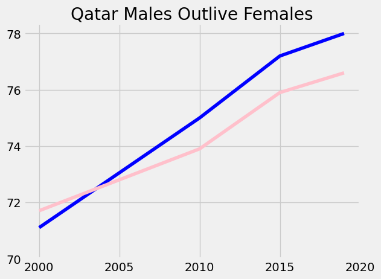

```python
plt.plot(qatar_data["Year"],qatar_data["Life expectancy at birth (years)  Male"], color="Blue")
plt.plot(qatar_data["Year"],qatar_data["Life expectancy at birth (years)  Female"], color="Pink")

plt.xticks([2000,2005,2010,2015,2020])
plt.yticks([70,72,74,76,78])
plt.title("Qatar Males Outlive Females")
plt.show()
```

# Part 3a: By Country - vs. Global Average

Let's begin our Life Expectancy Analysis by Country. First, we will compare the average global life expectancy and each country's average life expectancy. We will look for any standouts in each direction. This will answer our question of which countries have the highest/lowest values.

```python
country_expectancy.head()
```

|  | Countries, territories and areas | Year | Life expectancy at birth (years) Both sexes | Life expectancy at birth (years) Male | Life expectancy at birth (years) Female | Life expectancy at age 60 (years) Both sexes | Life expectancy at age 60 (years) Male | Life expectancy at age 60 (years) Female | Healthy life expectancy (HALE) at birth (years) Both sexes | Healthy life expectancy (HALE) at birth (years) Male | Healthy life expectancy (HALE) at birth (years) Female | Healthy life expectancy (HALE) at age 60 (years) Both sexes | Healthy life expectancy (HALE) at age 60 (years) Male | Healthy life expectancy (HALE) at age 60 (years) Female |
| --- | --- | --- | --- | --- | --- | --- | --- | --- | --- | --- | --- | --- | --- | --- |
| 0 | Afghanistan | 2019 | 63.2 | 63.3 | 63.2 | 15.2 | 15.4 | 15.1 | 53.9 | 54.7 | 53.2 | 10.8 | 11.2 | 10.6 |
| 1 | Afghanistan | 2015 | 61.7 | 61.0 | 62.3 | 15.6 | 15.7 | 15.5 | 52.6 | 52.8 | 52.4 | 11.2 | 11.5 | 10.9 |
| 2 | Afghanistan | 2010 | 59.9 | 59.6 | 60.3 | 15.1 | 15.1 | 15.2 | 51.1 | 51.5 | 50.7 | 10.9 | 11.1 | 10.7 |
| 3 | Afghanistan | 2000 | 55.0 | 54.6 | 55.4 | 13.9 | 13.6 | 14.2 | 46.8 | 46.9 | 46.6 | 10.2 | 10.2 | 10.1 |
| 4 | Albania | 2019 | 78.0 | 76.3 | 79.9 | 21.0 | 20.2 | 21.9 | 69.1 | 68.0 | 70.3 | 16.6 | 15.9 | 17.3 |

```python
# Generating a list of country names for reference
countries = []
for country in country_expectancy["Countries, territories and areas"]:
    if country not in countries:
        countries.append(country)
```

```python
# Generating a new data frame for comparison
country_expectancy_comparison = country_expectancy.copy()
```

```python
# Calculating the difference between global values and country values

for year in years:

    global_row = global_vals[global_vals["Year"] == year]
    countries_byyear = country_expectancy_comparison[country_expectancy_comparison["Year"] == year]

    for col in countries_byyear.columns[2:]:
        difference = countries_byyear[col] - global_row[col].values
        country_expectancy_comparison.loc[countries_byyear.index, col] = difference
```

```python
country_expectancy_comparison.head()
```

|  | Countries, territories and areas | Year | Life expectancy at birth (years) Both sexes | Life expectancy at birth (years) Male | Life expectancy at birth (years) Female | Life expectancy at age 60 (years) Both sexes | Life expectancy at age 60 (years) Male | Life expectancy at age 60 (years) Female | Healthy life expectancy (HALE) at birth (years) Both sexes | Healthy life expectancy (HALE) at birth (years) Male | Healthy life expectancy (HALE) at birth (years) Female | Healthy life expectancy (HALE) at age 60 (years) Both sexes | Healthy life expectancy (HALE) at age 60 (years) Male | Healthy life expectancy (HALE) at age 60 (years) Female |
| --- | --- | --- | --- | --- | --- | --- | --- | --- | --- | --- | --- | --- | --- | --- |
| 0 | Afghanistan | 2019 | -10.1 | -7.5 | -12.7 | -5.9 | -4.1 | -7.6 | -9.8 | -7.8 | -11.7 | -5.0 | -3.6 | -6.0 |
| 1 | Afghanistan | 2015 | -10.6 | -8.8 | -12.6 | -5.2 | -3.4 | -6.8 | -10.3 | -8.9 | -11.8 | -4.3 | -3.1 | -5.5 |
| 2 | Afghanistan | 2010 | -10.6 | -8.4 | -12.9 | -5.0 | -3.3 | -6.5 | -10.4 | -8.7 | -12.2 | -4.2 | -3.0 | -5.4 |
| 3 | Afghanistan | 2000 | -11.8 | -9.8 | -13.9 | -4.9 | -3.6 | -6.2 | -11.5 | -10.2 | -13.0 | -3.9 | -2.9 | -5.0 |
| 4 | Albania | 2019 | 4.7 | 5.5 | 4.0 | -0.1 | 0.7 | -0.8 | 5.4 | 5.5 | 5.4 | 0.8 | 1.1 | 0.7 |

```python
# Calculating the average difference for each country

country_expectancy_comparison_avg = country_expectancy_comparison.copy()

for country in countries:
    country_data = country_expectancy_comparison[country_expectancy_comparison["Countries, territories and areas"] == country]

    for col in country_data.columns[2:]:
        average = country_data[col].mean()
        country_expectancy_comparison_avg.loc[country_expectancy_comparison_avg["Countries, territories and areas"] == country, col] = average
```

```python
# Dropping duplicate rows and the year column
country_expectancy_comparison_avg.drop("Year", axis=1, inplace=True)
country_expectancy_comparison_avg.drop_duplicates(subset="Countries, territories and areas", keep="first", inplace=True)
```

```python
country_expectancy_comparison_avg.head()
```

|  | Countries, territories and areas | Life expectancy at birth (years) Both sexes | Life expectancy at birth (years) Male | Life expectancy at birth (years) Female | Life expectancy at age 60 (years) Both sexes | Life expectancy at age 60 (years) Male | Life expectancy at age 60 (years) Female | Healthy life expectancy (HALE) at birth (years) Both sexes | Healthy life expectancy (HALE) at birth (years) Male | Healthy life expectancy (HALE) at birth (years) Female | Healthy life expectancy (HALE) at age 60 (years) Both sexes | Healthy life expectancy (HALE) at age 60 (years) Male | Healthy life expectancy (HALE) at age 60 (years) Female |
| --- | --- | --- | --- | --- | --- | --- | --- | --- | --- | --- | --- | --- | --- |
| 0 | Afghanistan | -10.775 | -8.625 | -13.025 | -5.250 | -3.600 | -6.775000e+00 | -10.500 | -8.900 | -12.175 | -4.350 | -3.150 | -5.475 |
| 4 | Albania | 5.650 | 6.075 | 5.375 | 0.400 | 0.775 | 2.000000e-01 | 6.125 | 5.975 | 6.350 | 1.125 | 1.100 | 1.250 |
| 8 | Algeria | 4.700 | 6.175 | 3.150 | 1.050 | 2.225 | 8.881784e-16 | 3.550 | 5.000 | 2.050 | 0.400 | 1.300 | -0.400 |
| 12 | Angola | -12.675 | -12.650 | -12.675 | -4.175 | -4.150 | -4.150000e+00 | -11.100 | -11.300 | -10.850 | -3.225 | -3.300 | -3.050 |
| 16 | Antigua and Barbuda | 5.050 | 5.475 | 4.425 | 0.250 | 0.850 | -3.750000e-01 | 4.900 | 4.950 | 4.725 | 0.650 | 0.875 | 0.425 |

```python
# Isolating the top and bottom 10 countries
top_10_countries = country_expectancy_comparison_avg.nlargest(10, "Life expectancy at birth (years)  Both sexes")
bottom_10_countries = country_expectancy_comparison_avg.nsmallest(10, "Life expectancy at birth (years)  Both sexes")
```

```python
top_10_countries
```

|  | Countries, territories and areas | Life expectancy at birth (years) Both sexes | Life expectancy at birth (years) Male | Life expectancy at birth (years) Female | Life expectancy at age 60 (years) Both sexes | Life expectancy at age 60 (years) Male | Life expectancy at age 60 (years) Female | Healthy life expectancy (HALE) at birth (years) Both sexes | Healthy life expectancy (HALE) at birth (years) Male | Healthy life expectancy (HALE) at birth (years) Female | Healthy life expectancy (HALE) at age 60 (years) Both sexes | Healthy life expectancy (HALE) at age 60 (years) Male | Healthy life expectancy (HALE) at age 60 (years) Female |
| --- | --- | --- | --- | --- | --- | --- | --- | --- | --- | --- | --- | --- | --- |
| 332 | Japan | 12.200 | 11.600 | 12.550 | 5.200 | 4.250 | 5.975 | 11.475 | 10.925 | 11.800 | 4.575 | 3.775 | 5.225 |
| 632 | Switzerland | 11.250 | 11.575 | 10.700 | 4.250 | 4.225 | 4.175 | 9.625 | 10.100 | 9.025 | 3.650 | 3.600 | 3.650 |
| 28 | Australia | 11.000 | 11.400 | 10.475 | 4.400 | 4.600 | 4.250 | 8.475 | 8.700 | 8.175 | 3.200 | 3.275 | 3.150 |
| 324 | Italy | 10.900 | 10.925 | 10.550 | 3.900 | 3.650 | 4.000 | 9.300 | 9.500 | 9.000 | 3.125 | 2.875 | 3.300 |
| 612 | Spain | 10.850 | 10.475 | 11.100 | 4.100 | 3.550 | 4.550 | 9.350 | 9.325 | 9.225 | 3.325 | 2.925 | 3.650 |
| 584 | Singapore | 10.800 | 11.075 | 10.450 | 3.850 | 3.700 | 3.925 | 10.550 | 10.575 | 10.450 | 3.600 | 3.375 | 3.750 |
| 296 | Iceland | 10.725 | 11.550 | 9.775 | 3.675 | 4.225 | 3.175 | 9.675 | 10.575 | 8.725 | 3.300 | 3.725 | 2.875 |
| 628 | Sweden | 10.525 | 11.125 | 9.775 | 3.450 | 3.650 | 3.225 | 9.500 | 10.225 | 8.675 | 3.150 | 3.325 | 2.925 |
| 168 | Cyprus | 10.475 | 10.850 | 10.000 | 3.425 | 3.575 | 3.225 | 9.375 | 9.875 | 8.825 | 2.925 | 3.000 | 2.850 |
| 320 | Israel | 10.450 | 10.950 | 9.725 | 3.625 | 3.925 | 3.225 | 9.600 | 10.275 | 8.775 | 3.325 | 3.625 | 3.025 |

```python
bottom_10_countries
```

|  | Countries, territories and areas | Life expectancy at birth (years) Both sexes | Life expectancy at birth (years) Male | Life expectancy at birth (years) Female | Life expectancy at age 60 (years) Both sexes | Life expectancy at age 60 (years) Male | Life expectancy at age 60 (years) Female | Healthy life expectancy (HALE) at birth (years) Both sexes | Healthy life expectancy (HALE) at birth (years) Male | Healthy life expectancy (HALE) at birth (years) Female | Healthy life expectancy (HALE) at age 60 (years) Both sexes | Healthy life expectancy (HALE) at age 60 (years) Male | Healthy life expectancy (HALE) at age 60 (years) Female |
| --- | --- | --- | --- | --- | --- | --- | --- | --- | --- | --- | --- | --- | --- |
| 372 | Lesotho | -22.325 | -22.550 | -21.775 | -7.000 | -7.675 | -6.525 | -19.275 | -19.700 | -18.625 | -5.425 | -6.100 | -4.950 |
| 124 | Central African Republic | -21.625 | -21.175 | -22.025 | -7.625 | -7.775 | -7.550 | -18.650 | -18.675 | -18.650 | -5.650 | -5.925 | -5.425 |
| 220 | Eswatini | -19.200 | -19.900 | -17.800 | -6.050 | -6.975 | -5.175 | -16.675 | -17.600 | -15.300 | -4.825 | -5.700 | -3.975 |
| 600 | Somalia | -17.475 | -17.425 | -17.325 | -6.325 | -6.100 | -6.300 | -14.675 | -14.850 | -14.350 | -4.425 | -4.400 | -4.275 |
| 284 | Haiti | -16.975 | -15.650 | -18.200 | -5.050 | -3.725 | -6.375 | -14.500 | -13.725 | -15.150 | -3.550 | -2.675 | -4.325 |
| 728 | Zimbabwe | -16.400 | -16.275 | -16.850 | -5.400 | -5.825 | -5.275 | -13.975 | -14.025 | -14.075 | -4.175 | -4.625 | -4.025 |
| 444 | Mozambique | -16.175 | -16.750 | -15.700 | -4.850 | -5.650 | -4.300 | -14.325 | -15.175 | -13.625 | -3.900 | -4.650 | -3.325 |
| 580 | Sierra Leone | -15.450 | -14.250 | -16.750 | -4.075 | -3.175 | -5.075 | -13.450 | -12.825 | -14.175 | -3.175 | -2.575 | -3.775 |
| 276 | Guinea-Bissau | -14.700 | -14.825 | -14.750 | -5.475 | -5.475 | -5.675 | -12.575 | -12.750 | -12.500 | -4.325 | -4.325 | -4.425 |
| 724 | Zambia | -14.675 | -14.400 | -15.150 | -4.900 | -5.050 | -4.900 | -12.725 | -12.850 | -12.675 | -3.475 | -3.775 | -3.275 |

## Life Expectancy Differences Map

Let's generate an interactive map to explore the differences in life expectancy across the globe.

```python
# Exploring the life expectancy differences on an interactive map

import plotly.express as px

fig = px.choropleth(
    country_expectancy_comparison_avg,
    locations="Countries, territories and areas",
    locationmode='country names',
    color='Life expectancy at birth (years)  Both sexes',
    color_continuous_scale='RdYlGn',
    hover_name="Countries, territories and areas",  # Display country name on hover
    #hover_data=["Life expectancy at birth (years)  Both sexes"],  # Additional data on hover
    title='Life Expectancy Differences Compared to the Global Average'
)

fig.update_layout(
    height=500,   # Increase map height
    width=1100,   # Increase map width
    title_font_size=24,   # Adjust title font size
    coloraxis_colorbar=dict(title="Difference (in Years)"),   # Customize color bar title
    margin=dict(l=0, r=0, b=30, t=60)   # Adjust margins
)

fig.show()
```

## Life Expectancy Differences: Top 10s

Let's generate a bar plot to display the top 10 and bottom 10 countries.

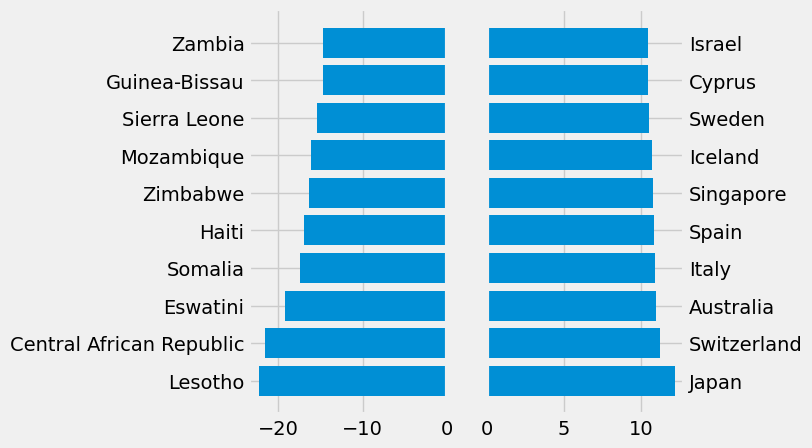

```python
# Exploring Life Expectancy Differences vs. Global Average

plt.figure(figsize=(5,5))

ax1 = plt.subplot(1,2,1)
ax1.barh(bottom_10_countries["Countries, territories and areas"], bottom_10_countries["Life expectancy at birth (years)  Both sexes"])
ax1.yaxis.tick_left()

ax2 = plt.subplot(1,2,2)
ax2.barh(top_10_countries["Countries, territories and areas"], top_10_countries["Life expectancy at birth (years)  Both sexes"])
ax2.yaxis.tick_right()

plt.show()
```

```python
# Sorting the top 10 and bottom 10
top_10_countries = top_10_countries.sort_values("Life expectancy at birth (years)  Both sexes", ascending=True)
bottom_10_countries = bottom_10_countries.sort_values("Life expectancy at birth (years)  Both sexes", ascending=False)
```

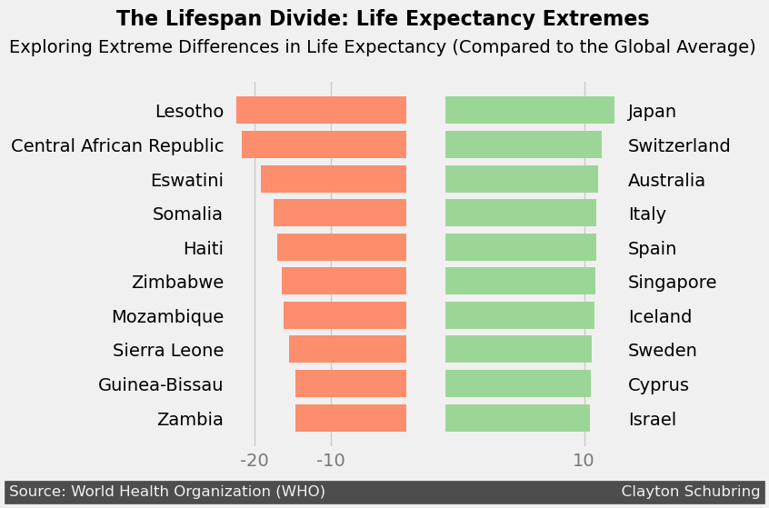

```python
# Fig 2: Lifespan Extremes by Country

# Generating the figure
plt.figure(figsize=(5,5))
ax1 = plt.subplot(1,2,1)
ax2 = plt.subplot(1,2,2)

# Generating colormaps
gmap = plt.colormaps['Greens']
rmap = plt.colormaps['Reds']

# Generating country labels
top_10_labels = top_10_countries["Countries, territories and areas"]
bottom_10_labels = bottom_10_countries["Countries, territories and areas"]

# ax1: Bottom 10 countries
ax1.barh(bottom_10_countries["Countries, territories and areas"], bottom_10_countries["Life expectancy at birth (years)  Both sexes"], color=rmap(100))
ax1.yaxis.tick_left()
ax1.set_xticks([-20,-10,0])
ax1.set_xticklabels([-20,-10,""], alpha=0.5)
ax1.yaxis.grid(False)

# ax2: Top 10 countries
ax2.barh(top_10_countries["Countries, territories and areas"], top_10_countries["Life expectancy at birth (years)  Both sexes"], color=gmap(100))
ax2.yaxis.tick_right()
ax2.set_xticks([0,10])
ax2.set_xticklabels(["", 10], alpha=0.5)
ax2.yaxis.grid(False)

# Title
ax1.text(-38,11.5, "The Lifespan Divide: Life Expectancy Extremes", weight='bold', size=16)
ax1.text(-52,10.7, "Exploring Extreme Differences in Life Expectancy (Compared to the Global Average)")

# Signature
ax1.text(-52,-2.3,
        'Source: World Health Organization (WHO)' + ' '*62 + 'Clayton Schubring',
        color = '#f0f0f0',
        backgroundcolor = '#4d4d4d',
        size=12)


plt.show()
```

# Part 3b: By Country - Largest Change

This section will aim to find the largest changes in life expectancy from 2000 to 2019. Where did these changes occur?

```python
country_expectancy.head()
```

|  | Countries, territories and areas | Year | Life expectancy at birth (years) Both sexes | Life expectancy at birth (years) Male | Life expectancy at birth (years) Female | Life expectancy at age 60 (years) Both sexes | Life expectancy at age 60 (years) Male | Life expectancy at age 60 (years) Female | Healthy life expectancy (HALE) at birth (years) Both sexes | Healthy life expectancy (HALE) at birth (years) Male | Healthy life expectancy (HALE) at birth (years) Female | Healthy life expectancy (HALE) at age 60 (years) Both sexes | Healthy life expectancy (HALE) at age 60 (years) Male | Healthy life expectancy (HALE) at age 60 (years) Female |
| --- | --- | --- | --- | --- | --- | --- | --- | --- | --- | --- | --- | --- | --- | --- |
| 0 | Afghanistan | 2019 | 63.2 | 63.3 | 63.2 | 15.2 | 15.4 | 15.1 | 53.9 | 54.7 | 53.2 | 10.8 | 11.2 | 10.6 |
| 1 | Afghanistan | 2015 | 61.7 | 61.0 | 62.3 | 15.6 | 15.7 | 15.5 | 52.6 | 52.8 | 52.4 | 11.2 | 11.5 | 10.9 |
| 2 | Afghanistan | 2010 | 59.9 | 59.6 | 60.3 | 15.1 | 15.1 | 15.2 | 51.1 | 51.5 | 50.7 | 10.9 | 11.1 | 10.7 |
| 3 | Afghanistan | 2000 | 55.0 | 54.6 | 55.4 | 13.9 | 13.6 | 14.2 | 46.8 | 46.9 | 46.6 | 10.2 | 10.2 | 10.1 |
| 4 | Albania | 2019 | 78.0 | 76.3 | 79.9 | 21.0 | 20.2 | 21.9 | 69.1 | 68.0 | 70.3 | 16.6 | 15.9 | 17.3 |

```python
# Calculating net change from 2000 to 2020

net_change_expectancy=pd.DataFrame()
net_change_expectancy["Country"] = countries

for country in countries:

    country_data = country_expectancy[country_expectancy["Countries, territories and areas"] == country]

    val2019 = country_data.loc[country_data["Year"] == 2019 ,"Life expectancy at birth (years)  Both sexes"].iloc[0]
    val2000 = country_data.loc[country_data["Year"] == 2000 ,"Life expectancy at birth (years)  Both sexes"].iloc[0]

    net_change = val2019-val2000

    net_change_expectancy.loc[net_change_expectancy["Country"] == country, "Net Change"] = net_change
```

```python
net_change_expectancy
```

|  | Country | Net Change |
| --- | --- | --- |
| 0 | Afghanistan | 8.2 |
| 1 | Albania | 4.5 |
| 2 | Algeria | 4.9 |
| 3 | Angola | 13.8 |
| 4 | Antigua and Barbuda | 1.9 |
| ... | ... | ... |
| 178 | Venezuela (Bolivarian Republic of) | -0.2 |
| 179 | Viet Nam | 2.3 |
| 180 | Yemen | 3.9 |
| 181 | Zambia | 18.0 |
| 182 | Zimbabwe | 14.1 |

183 rows × 2 columns

```python
# Isolating the top and bottom 10
top_10_net_change = net_change_expectancy.nlargest(10, "Net Change")
bottom_10_net_change = net_change_expectancy.nsmallest(10, "Net Change")
```

```python
top_10_net_change
```

|  | Country | Net Change |
| --- | --- | --- |
| 136 | Rwanda | 21.6 |
| 99 | Malawi | 20.9 |
| 26 | Burundi | 20.0 |
| 56 | Ethiopia | 18.1 |
| 181 | Zambia | 18.0 |
| 169 | Uganda | 17.9 |
| 21 | Botswana | 16.6 |
| 173 | United Republic of Tanzania | 14.8 |
| 182 | Zimbabwe | 14.1 |
| 3 | Angola | 13.8 |

```python
bottom_10_net_change
```

|  | Country | Net Change |
| --- | --- | --- |
| 48 | Dominican Republic | -0.4 |
| 178 | Venezuela (Bolivarian Republic of) | -0.2 |
| 66 | Grenada | 0.9 |
| 41 | Cuba | 1.0 |
| 125 | Paraguay | 1.0 |
| 137 | Saint Lucia | 1.1 |
| 159 | Syrian Arab Republic | 1.2 |
| 20 | Bosnia and Herzegovina | 1.4 |
| 95 | Libya | 1.4 |
| 144 | Seychelles | 1.4 |

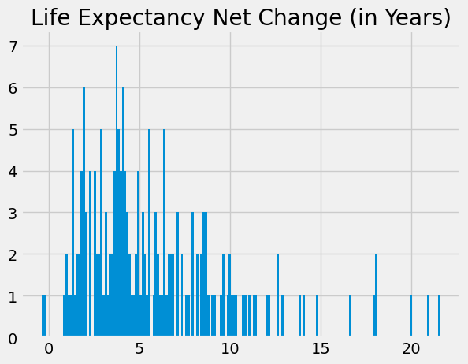

```python
# Net Change Histogram

plt.hist(net_change_expectancy["Net Change"], bins=183)
plt.title("Life Expectancy Net Change (in Years)")
plt.show()
```

```python
# Finding Outliers

mean_change = net_change_expectancy["Net Change"].mean()
std_change = net_change_expectancy["Net Change"].std()

threshold = 3
lower_bound = mean_change - threshold * std_change
upper_bound = mean_change + threshold * std_change

outliers = net_change_expectancy[(net_change_expectancy["Net Change"] < lower_bound) | (net_change_expectancy["Net Change"] > upper_bound)]

print(outliers)
```

```
      Country  Net Change
26    Burundi        20.0
56   Ethiopia        18.1
99     Malawi        20.9
136    Rwanda        21.6
```

```python
country_expectancy[country_expectancy["Countries, territories and areas"]=="Burundi"]
```

|  | Countries, territories and areas | Year | Life expectancy at birth (years) Both sexes | Life expectancy at birth (years) Male | Life expectancy at birth (years) Female | Life expectancy at age 60 (years) Both sexes | Life expectancy at age 60 (years) Male | Life expectancy at age 60 (years) Female | Healthy life expectancy (HALE) at birth (years) Both sexes | Healthy life expectancy (HALE) at birth (years) Male | Healthy life expectancy (HALE) at birth (years) Female | Healthy life expectancy (HALE) at age 60 (years) Both sexes | Healthy life expectancy (HALE) at age 60 (years) Male | Healthy life expectancy (HALE) at age 60 (years) Female |
| --- | --- | --- | --- | --- | --- | --- | --- | --- | --- | --- | --- | --- | --- | --- |
| 104 | Burundi | 2019 | 63.8 | 61.5 | 66.1 | 16.5 | 15.2 | 17.6 | 55.6 | 54.0 | 57.2 | 12.7 | 11.8 | 13.5 |
| 105 | Burundi | 2015 | 62.0 | 59.8 | 64.3 | 16.2 | 14.9 | 17.4 | 54.0 | 52.4 | 55.6 | 12.4 | 11.5 | 13.3 |
| 106 | Burundi | 2010 | 58.6 | 56.9 | 60.3 | 15.6 | 14.2 | 16.8 | 50.9 | 49.6 | 52.1 | 12.0 | 11.0 | 12.8 |
| 107 | Burundi | 2000 | 43.8 | 41.8 | 45.9 | 13.0 | 11.8 | 14.0 | 38.1 | 36.6 | 39.7 | 9.9 | 9.1 | 10.6 |

```python
country_expectancy[country_expectancy["Countries, territories and areas"]=="Ethiopia"]
```

|  | Countries, territories and areas | Year | Life expectancy at birth (years) Both sexes | Life expectancy at birth (years) Male | Life expectancy at birth (years) Female | Life expectancy at age 60 (years) Both sexes | Life expectancy at age 60 (years) Male | Life expectancy at age 60 (years) Female | Healthy life expectancy (HALE) at birth (years) Both sexes | Healthy life expectancy (HALE) at birth (years) Male | Healthy life expectancy (HALE) at birth (years) Female | Healthy life expectancy (HALE) at age 60 (years) Both sexes | Healthy life expectancy (HALE) at age 60 (years) Male | Healthy life expectancy (HALE) at age 60 (years) Female |
| --- | --- | --- | --- | --- | --- | --- | --- | --- | --- | --- | --- | --- | --- | --- |
| 224 | Ethiopia | 2019 | 68.7 | 66.9 | 70.5 | 18.4 | 17.4 | 19.4 | 59.9 | 59.0 | 60.8 | 13.9 | 13.3 | 14.4 |
| 225 | Ethiopia | 2015 | 66.8 | 65.0 | 68.6 | 18.1 | 17.0 | 19.1 | 58.3 | 57.4 | 59.3 | 13.6 | 13.0 | 14.2 |
| 226 | Ethiopia | 2010 | 62.9 | 61.3 | 64.5 | 17.3 | 16.3 | 18.3 | 55.0 | 54.2 | 55.8 | 13.0 | 12.5 | 13.5 |
| 227 | Ethiopia | 2000 | 50.6 | 49.5 | 51.7 | 14.1 | 13.4 | 14.9 | 44.3 | 43.9 | 44.8 | 10.6 | 10.2 | 11.0 |

```python
country_expectancy[country_expectancy["Countries, territories and areas"]=="Malawi"]
```

|  | Countries, territories and areas | Year | Life expectancy at birth (years) Both sexes | Life expectancy at birth (years) Male | Life expectancy at birth (years) Female | Life expectancy at age 60 (years) Both sexes | Life expectancy at age 60 (years) Male | Life expectancy at age 60 (years) Female | Healthy life expectancy (HALE) at birth (years) Both sexes | Healthy life expectancy (HALE) at birth (years) Male | Healthy life expectancy (HALE) at birth (years) Female | Healthy life expectancy (HALE) at age 60 (years) Both sexes | Healthy life expectancy (HALE) at age 60 (years) Male | Healthy life expectancy (HALE) at age 60 (years) Female |
| --- | --- | --- | --- | --- | --- | --- | --- | --- | --- | --- | --- | --- | --- | --- |
| 396 | Malawi | 2019 | 65.6 | 62.3 | 68.9 | 17.2 | 15.1 | 19.0 | 57.1 | 55.1 | 59.0 | 12.8 | 11.3 | 14.0 |
| 397 | Malawi | 2015 | 63.0 | 59.7 | 66.5 | 16.9 | 14.6 | 18.8 | 54.9 | 52.8 | 57.0 | 12.5 | 10.9 | 13.9 |
| 398 | Malawi | 2010 | 56.8 | 54.4 | 59.2 | 16.0 | 13.7 | 18.0 | 49.6 | 48.3 | 50.9 | 11.8 | 10.2 | 13.2 |
| 399 | Malawi | 2000 | 44.7 | 44.0 | 45.6 | 14.0 | 12.2 | 15.8 | 39.1 | 38.9 | 39.3 | 10.3 | 9.1 | 11.5 |

```python
country_expectancy[country_expectancy["Countries, territories and areas"]=="Rwanda"]
```

|  | Countries, territories and areas | Year | Life expectancy at birth (years) Both sexes | Life expectancy at birth (years) Male | Life expectancy at birth (years) Female | Life expectancy at age 60 (years) Both sexes | Life expectancy at age 60 (years) Male | Life expectancy at age 60 (years) Female | Healthy life expectancy (HALE) at birth (years) Both sexes | Healthy life expectancy (HALE) at birth (years) Male | Healthy life expectancy (HALE) at birth (years) Female | Healthy life expectancy (HALE) at age 60 (years) Both sexes | Healthy life expectancy (HALE) at age 60 (years) Male | Healthy life expectancy (HALE) at age 60 (years) Female |
| --- | --- | --- | --- | --- | --- | --- | --- | --- | --- | --- | --- | --- | --- | --- |
| 544 | Rwanda | 2019 | 69.1 | 66.9 | 71.2 | 18.0 | 16.6 | 19.2 | 60.2 | 59.0 | 61.4 | 13.6 | 12.7 | 14.4 |
| 545 | Rwanda | 2015 | 67.7 | 65.5 | 69.8 | 17.9 | 16.5 | 19.1 | 58.9 | 57.6 | 60.1 | 13.5 | 12.5 | 14.3 |
| 546 | Rwanda | 2010 | 64.4 | 62.3 | 66.5 | 17.4 | 15.9 | 18.6 | 55.9 | 54.8 | 57.1 | 13.1 | 12.1 | 13.9 |
| 547 | Rwanda | 2000 | 47.5 | 45.9 | 49.2 | 13.4 | 11.8 | 15.0 | 41.2 | 40.4 | 42.0 | 10.0 | 9.0 | 11.1 |

## Life Expectancy Net Change Map

Everything looks good, let's proceed. A good way to visualize this net change globally would be to view all values on an interactive map.

```python
# Generating a map of net change

fig = px.choropleth(
    net_change_expectancy,
    locations="Country",
    locationmode='country names',
    color='Net Change',
    color_continuous_scale='BuGn',
    hover_name="Country",  # Display country name on hover
    #hover_data=["Life expectancy at birth (years)  Both sexes"],  # Additional data on hover
    title='Life Expectancy Net Change, 2000-2020:'
)

fig.update_layout(
    height=500,   # Increase map height
    width=1100,   # Increase map width
    title_font_size=24,   # Adjust title font size
    coloraxis_colorbar=dict(title="Increase (in Years)"),   # Customize color bar title
    margin=dict(l=0, r=0, b=30, t=60)   # Adjust margins
)

fig.show()
```

```python
# Isolating top 10 countries and indexing the country data

top_10_movers_countries = []
for country in top_10_net_change["Country"]:
    top_10_movers_countries.append(country)

top_10_movers = country_expectancy[country_expectancy["Countries, territories and areas"].isin(top_10_movers_countries)]

top_10_movers_countries
```

```
['Rwanda',
 'Malawi',
 'Burundi',
 'Ethiopia',
 'Zambia',
 'Uganda',
 'Botswana',
 'United Republic of Tanzania',
 'Zimbabwe',
 'Angola']
```

## Top 10 Net Change is African

It seems that all top 10 net changes occured in African countries. Let's now display this finding:

[figure not shown]

```python
#Africa's Rise: Top Movers are all African Countries

fig,ax=plt.subplots(figsize=(9,5))
colors = [
    "#4E342E", "#6D4C41", "#8D6E63", "#BCAAA4", "#D7CCC8",
    "#A1887F", "#E0E0E0", "#B0BEC5", "#90A4AE", "#78909C"
]
for country, color in zip(top_10_movers_countries, colors):

    country_data = top_10_movers[top_10_movers["Countries, territories and areas"]==country]
    ax.plot(country_data["Year"] ,country_data["Life expectancy at birth (years)  Both sexes"], label=country, color=color)

ax.legend(loc='upper right')
ax.set_ylim(30,75)
ax.set_xticks([2000,2005,2010,2015])
ax.set_xlim(1999.9,2035)
ax.set_yticks([40,50,60,70])
ax.grid(alpha=0.4)
ax.set_xticklabels(["",2005,"",2010],alpha=0.5)
ax.set_yticklabels([40,50,60,70],alpha=0.5)

ax.text(2006,79,"Africa's Rise: Life Expectancy Trends ",weight='bold', fontsize=16)
ax.text(2003.5,76,"Witnessing a Surge in Life Expectancy Across African Nations")


plt.show()
```

```python
# Isolating the bottom 10 and indexing the country data

bottom_10_movers_countries = []
for country in bottom_10_net_change["Country"]:
    bottom_10_movers_countries.append(country)


bottom_10_movers = country_expectancy[country_expectancy["Countries, territories and areas"].isin(bottom_10_movers_countries)]

bottom_10_movers_countries
```

```
['Dominican Republic',
 'Venezuela (Bolivarian Republic of)',
 'Grenada',
 'Cuba',
 'Paraguay',
 'Saint Lucia',
 'Syrian Arab Republic',
 'Bosnia and Herzegovina',
 'Libya',
 'Seychelles']
```

```python
#Isolating the bottom 5 Caribbean countries

bottom_5_movers_countries = bottom_10_movers_countries[:5]
bottom_5_movers = bottom_10_movers[bottom_10_movers["Countries, territories and areas"].isin(bottom_5_movers_countries)]
```

[figure not shown]

```python
# Lowest Movers: Caribbean Countries

fig,ax=plt.subplots(figsize=(9,5))
colors = ["#4E342E", "#6D4C41", "#8D6E63", "#BCAAA4", "#D7CCC8"]

for country, color in zip(bottom_5_movers_countries, colors):

    country_data = bottom_5_movers[bottom_5_movers["Countries, territories and areas"]==country]
    ax.plot(country_data["Year"] ,country_data["Life expectancy at birth (years)  Both sexes"], label=country, color=color)

ax.legend(loc='lower right')
ax.set_ylim(65,80)
ax.set_xticks([2000,2005,2010,2015])
ax.set_xlim(1999.9,2035)
ax.set_yticks([65,70,75,80])
ax.grid(alpha=0.4)
ax.set_xticklabels(["",2005,"",2010],alpha=0.5)
ax.set_yticklabels(["",70,75,80],alpha=0.5)
ax.text(2002,81.5,"Meanwhile, Caribbean Life Expectancy Trends Are Stagnant")

plt.show()
```

## Top GDP and Global Trend

It would be nice to have a third figure that showcases the global trend to furthermore highlight how unusual the above finding is. The countries with the highest GDPs should produce a good indicator of the primary global trend. Let's add this and combine everything to produce the final figure.

```python
# Finding Highest GDP Countries

highest_gdp_countries = [
    "United States of America",
    "China",
    "Japan",
    "Germany",
    "India",
    "United Kingdom of Great Britain and Northern Ireland",
    "France",
    "Brazil",
    "Italy",
    "Canada"
]

highest_gdp_expectancy = country_expectancy[country_expectancy["Countries, territories and areas"].isin(highest_gdp_countries)]
```

## Global Life Expectancy Trends, 2000-2020

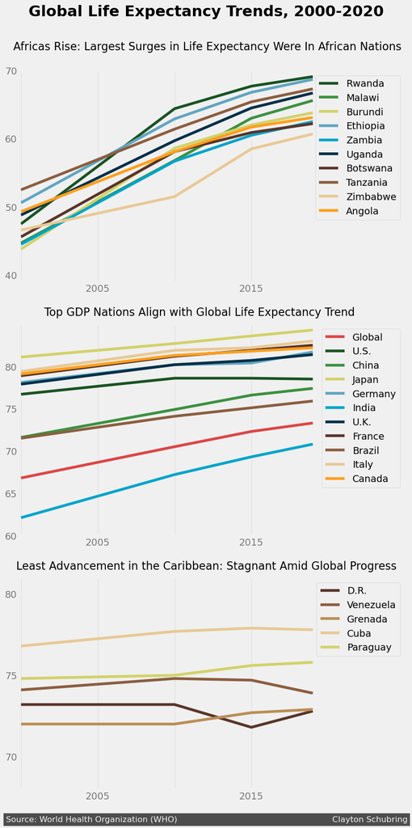

```python
#Fig. 3.2 : Global Life Expectancy Trends, 2000-2020

# Generating the figure
fig=plt.figure(figsize=(9,18))
ax1 = plt.subplot(3,1,1)
ax2 = plt.subplot(3,1,2)
ax3 = plt.subplot(3,1,3)


# Colors
colors_10 = ["#1A5324","#3D9140","#d2d26a","#61A5C2",
     "#00A4CC", "#003049", "#5A352A", "#8C5E40",  "#E8C995", "#FF9F1C"]

colors_5 = ["#5A352A", "#8C5E40", "#BB8E56", "#E8C995", "#d2d26a"]

# Title
ax1.text(2000.5,78,"Global Life Expectancy Trends, 2000-2020",weight='bold', fontsize=22)

# ax1: Top 10 and Africa
top_10_movers_labels = ["Rwanda", "Malawi", "Burundi", "Ethiopia", "Zambia", "Uganda", "Botswana", "Tanzania", "Zimbabwe", "Angola"]

for country, color, label in zip(top_10_movers_countries, colors_10, top_10_movers_labels):

    country_data = top_10_movers[top_10_movers["Countries, territories and areas"]==country]
    ax1.plot(country_data["Year"] ,country_data["Life expectancy at birth (years)  Both sexes"], label=label, color=color)

ax1.legend(loc='upper right')
ax1.set_ylim(39,70)
ax1.set_xticks([2000,2005,2010,2015])
ax1.set_xlim(1999.9,2025)
ax1.set_yticks([40,50,60,70])
ax1.grid(alpha=0.4)
ax1.set_xticklabels(["",2005,"",2015],alpha=0.5)
ax1.set_yticklabels([40,50,60,70],alpha=0.5)
ax1.text(1999.5,73,"Africas Rise: Largest Surges in Life Expectancy Were In African Nations",fontsize=16)
ax1.yaxis.grid(False)

# ax2: Highest GDP and Global Trend
highest_gdp_labels = ["U.S.", "China", "Japan", "Germany", "India", "U.K.", "France", "Brazil", "Italy", "Canada"]
ax2.plot(global_expectancy["Year"], global_expectancy["Life expectancy at birth (years)  Both sexes"], label="Global", color="#dd4646")
for country, color, label in zip(highest_gdp_countries, colors_10, highest_gdp_labels):
    country_data = highest_gdp_expectancy[highest_gdp_expectancy["Countries, territories and areas"]==country]
    ax2.plot(country_data["Year"] ,country_data["Life expectancy at birth (years)  Both sexes"], label=label, color=color)
ax2.legend(loc='upper right')
ax2.set_ylim(60,85)
ax2.set_xticks([2000,2005,2010,2015])
ax2.set_xlim(1999.9,2025)
ax2.set_yticks([60,65,70,75,80])
ax2.grid(alpha=0.4)
ax2.set_xticklabels(["",2005,"",2015],alpha=0.5)
ax2.set_yticklabels([60,65,70,75,80],alpha=0.5)
ax2.yaxis.grid(False)
ax2.text(2001.5,86,"Top GDP Nations Align with Global Life Expectancy Trend",fontsize=16)

# ax3: Bottom 5 and Caribbean
bottom_5_movers_labels = ["D.R.", "Venezuela", "Grenada", "Cuba", "Paraguay"]

for country, color, label in zip(bottom_5_movers_countries, colors_5, bottom_5_movers_labels):

    country_data = bottom_5_movers[bottom_5_movers["Countries, territories and areas"] == country]
    ax3.plot(country_data["Year"] ,country_data["Life expectancy at birth (years)  Both sexes"], label=label, color=color)

ax3.legend(loc='upper right')
ax3.set_ylim(68,81)
ax3.set_xticks([2000,2005,2010,2015])
ax3.set_xlim(1999.9,2025)
ax3.set_yticks([70,75,80])
ax3.grid(alpha=0.4)
ax3.set_xticklabels(["",2005,"",2015],alpha=0.5)
ax3.set_yticklabels([70,75,80],alpha=0.5)
ax3.text(1999.7,81.5,"Least Advancement in the Caribbean: Stagnant Amid Global Progress",fontsize=16)
ax3.yaxis.grid(False)


# Signature
ax3.text(1999,66,
        'Source: World Health Organization (WHO)' + ' '*60 + 'Clayton Schubring',
        color = '#f0f0f0',
        backgroundcolor = '#4d4d4d',
        size=12)


plt.show()
```

# Conclusion

This concludes our analysis of life expectancy from 2000 - 2020. We have sucessfully found and displayed the following results:

Life Expectancy Income Gap is Decreasing.

Life Expectancy Gender Gap has no Clear Global Trend.

Highest Life Expectancy Gender Gap is in Eastern Europe.

Lowest Life Expectancy Gender Gap is in Qatar (Males Outlive Females).

Largest (Positive) Net Change in Life Expectancy was in African Countries.

Top GDP Countries align with the Global Trends in Life Expectancy.